# Histamine H1 receptor

```python
import pandas as pd
from chembl_webresource_client.new_client import new_client
```

```python
target = new_client.target
target_query = target.search('CHEMBL231')
targets = pd.DataFrame.from_dict(target_query)
targets
```

|  | cross_references | organism | pref_name | score | species_group_flag | target_chembl_id | target_components | target_type | tax_id |
| --- | --- | --- | --- | --- | --- | --- | --- | --- | --- |
| 0 | [] | Homo sapiens | Histamine H1 receptor | 17.0 | False | CHEMBL231 | [{'accession': 'P35367', 'component_descriptio... | SINGLE PROTEIN | 9606 |

```python
selected_target = targets.target_chembl_id[0]
selected_target
```

```
'CHEMBL231'
```

```python
activity = new_client.activity
res = activity.filter(target_chembl_id=selected_target).filter(standard_type="IC50")
```

```python
df = pd.DataFrame.from_dict(res)
```

```python
print(len(res))
```

```
1300
```

```python
df.head()
```

|  | action_type | activity_comment | activity_id | activity_properties | assay_chembl_id | assay_description | assay_type | assay_variant_accession | assay_variant_mutation | bao_endpoint | ... | target_organism | target_pref_name | target_tax_id | text_value | toid | type | units | uo_units | upper_value | value |
| --- | --- | --- | --- | --- | --- | --- | --- | --- | --- | --- | --- | --- | --- | --- | --- | --- | --- | --- | --- | --- | --- |
| 0 | None | None | 146647 | [] | CHEMBL692983 | Inhibitory activity against human Histamine H1... | B | None | None | BAO_0000190 | ... | Homo sapiens | Histamine H1 receptor | 9606 | None | None | Log IC50 | None | UO_0000065 | None | -5.9 |
| 1 | None | None | 149038 | [] | CHEMBL692983 | Inhibitory activity against human Histamine H1... | B | None | None | BAO_0000190 | ... | Homo sapiens | Histamine H1 receptor | 9606 | None | None | Log IC50 | None | UO_0000065 | None | -5.9 |
| 2 | None | None | 149041 | [] | CHEMBL692983 | Inhibitory activity against human Histamine H1... | B | None | None | BAO_0000190 | ... | Homo sapiens | Histamine H1 receptor | 9606 | None | None | Log IC50 | None | UO_0000065 | None | -6.0 |
| 3 | None | None | 150189 | [] | CHEMBL692983 | Inhibitory activity against human Histamine H1... | B | None | None | BAO_0000190 | ... | Homo sapiens | Histamine H1 receptor | 9606 | None | None | Log IC50 | None | UO_0000065 | None | -5.6 |
| 4 | None | None | 152698 | [] | CHEMBL692983 | Inhibitory activity against human Histamine H1... | B | None | None | BAO_0000190 | ... | Homo sapiens | Histamine H1 receptor | 9606 | None | None | Log IC50 | None | UO_0000065 | None | -6.3 |

5 rows × 46 columns

```python
df.tail()
```

|  | action_type | activity_comment | activity_id | activity_properties | assay_chembl_id | assay_description | assay_type | assay_variant_accession | assay_variant_mutation | bao_endpoint | ... | target_organism | target_pref_name | target_tax_id | text_value | toid | type | units | uo_units | upper_value | value |
| --- | --- | --- | --- | --- | --- | --- | --- | --- | --- | --- | --- | --- | --- | --- | --- | --- | --- | --- | --- | --- | --- |
| 1295 | {'action_type': 'INHIBITOR', 'description': 'N... | None | 25523852 | [] | CHEMBL5338203 | Inhibition of human H1 receptor | B | None | None | BAO_0000190 | ... | Homo sapiens | Histamine H1 receptor | 9606 | None | None | IC50 | uM | UO_0000065 | None | 8.0 |
| 1296 | {'action_type': 'INHIBITOR', 'description': 'N... | None | 25658311 | [{'comments': None, 'relation': '=', 'result_f... | CHEMBL5372886 | Displacement of [3H] pyrilamine from human rec... | B | None | None | BAO_0000190 | ... | Homo sapiens | Histamine H1 receptor | 9606 | None | None | IC50 | uM | UO_0000065 | None | 0.34 |
| 1297 | {'action_type': 'INHIBITOR', 'description': 'N... | None | 25658312 | [{'comments': None, 'relation': '=', 'result_f... | CHEMBL5372886 | Displacement of [3H] pyrilamine from human rec... | B | None | None | BAO_0000190 | ... | Homo sapiens | Histamine H1 receptor | 9606 | None | None | IC50 | uM | UO_0000065 | None | 0.52 |
| 1298 | None | None | 25778417 | [{'comments': None, 'relation': '=', 'result_f... | CHEMBL5465586 | Selectivity interaction (BET inhibitor selecti... | B | None | None | BAO_0000190 | ... | Homo sapiens | Histamine H1 receptor | 9606 | None | None | IC50 | uM | UO_0000065 | None | 31.6 |
| 1299 | None | None | 25787560 | [{'comments': None, 'relation': None, 'result_... | CHEMBL5474422 | Selectivity interaction (Histamine H1 receptor... | B | None | None | BAO_0000190 | ... | Homo sapiens | Histamine H1 receptor | 9606 | None | None | IC50 | uM | UO_0000065 | None | 30.0 |

5 rows × 46 columns

```python
df.info()
```

```
<class 'pandas.core.frame.DataFrame'>
RangeIndex: 1300 entries, 0 to 1299
Data columns (total 46 columns):
 #   Column                     Non-Null Count  Dtype
---  ------                     --------------  -----
 0   action_type                9 non-null      object
 1   activity_comment           848 non-null    object
 2   activity_id                1300 non-null   int64
 3   activity_properties        1300 non-null   object
 4   assay_chembl_id            1300 non-null   object
 5   assay_description          1300 non-null   object
 6   assay_type                 1300 non-null   object
 7   assay_variant_accession    1 non-null      object
 8   assay_variant_mutation     1 non-null      object
 9   bao_endpoint               1300 non-null   object
```

[output cut: 38 more lines]

```python
df.columns
```

```
Index(['action_type', 'activity_comment', 'activity_id', 'activity_properties',
       'assay_chembl_id', 'assay_description', 'assay_type',
       'assay_variant_accession', 'assay_variant_mutation', 'bao_endpoint',
       'bao_format', 'bao_label', 'canonical_smiles', 'data_validity_comment',
       'data_validity_description', 'document_chembl_id', 'document_journal',
       'document_year', 'ligand_efficiency', 'molecule_chembl_id',
       'molecule_pref_name', 'parent_molecule_chembl_id', 'pchembl_value',
       'potential_duplicate', 'qudt_units', 'record_id', 'relation', 'src_id',
       'standard_flag', 'standard_relation', 'standard_text_value',
       'standard_type', 'standard_units', 'standard_upper_value',
       'standard_value', 'target_chembl_id', 'target_organism',
       'target_pref_name', 'target_tax_id', 'text_value', 'toid', 'type',
       'units', 'uo_units', 'upper_value', 'value'],
      dtype='object')
```

```python
df2 = df.dropna(subset=["standard_value", "canonical_smiles"])
```

```python
df2
```

|  | action_type | activity_comment | activity_id | activity_properties | assay_chembl_id | assay_description | assay_type | assay_variant_accession | assay_variant_mutation | bao_endpoint | ... | target_organism | target_pref_name | target_tax_id | text_value | toid | type | units | uo_units | upper_value | value |
| --- | --- | --- | --- | --- | --- | --- | --- | --- | --- | --- | --- | --- | --- | --- | --- | --- | --- | --- | --- | --- | --- |
| 0 | None | None | 146647 | [] | CHEMBL692983 | Inhibitory activity against human Histamine H1... | B | None | None | BAO_0000190 | ... | Homo sapiens | Histamine H1 receptor | 9606 | None | None | Log IC50 | None | UO_0000065 | None | -5.9 |
| 1 | None | None | 149038 | [] | CHEMBL692983 | Inhibitory activity against human Histamine H1... | B | None | None | BAO_0000190 | ... | Homo sapiens | Histamine H1 receptor | 9606 | None | None | Log IC50 | None | UO_0000065 | None | -5.9 |
| 2 | None | None | 149041 | [] | CHEMBL692983 | Inhibitory activity against human Histamine H1... | B | None | None | BAO_0000190 | ... | Homo sapiens | Histamine H1 receptor | 9606 | None | None | Log IC50 | None | UO_0000065 | None | -6.0 |
| 3 | None | None | 150189 | [] | CHEMBL692983 | Inhibitory activity against human Histamine H1... | B | None | None | BAO_0000190 | ... | Homo sapiens | Histamine H1 receptor | 9606 | None | None | Log IC50 | None | UO_0000065 | None | -5.6 |
| 4 | None | None | 152698 | [] | CHEMBL692983 | Inhibitory activity against human Histamine H1... | B | None | None | BAO_0000190 | ... | Homo sapiens | Histamine H1 receptor | 9606 | None | None | Log IC50 | None | UO_0000065 | None | -6.3 |
| ... | ... | ... | ... | ... | ... | ... | ... | ... | ... | ... | ... | ... | ... | ... | ... | ... | ... | ... | ... | ... | ... |
| 1295 | {'action_type': 'INHIBITOR', 'description': 'N... | None | 25523852 | [] | CHEMBL5338203 | Inhibition of human H1 receptor | B | None | None | BAO_0000190 | ... | Homo sapiens | Histamine H1 receptor | 9606 | None | None | IC50 | uM | UO_0000065 | None | 8.0 |
| 1296 | {'action_type': 'INHIBITOR', 'description': 'N... | None | 25658311 | [{'comments': None, 'relation': '=', 'result_f... | CHEMBL5372886 | Displacement of [3H] pyrilamine from human rec... | B | None | None | BAO_0000190 | ... | Homo sapiens | Histamine H1 receptor | 9606 | None | None | IC50 | uM | UO_0000065 | None | 0.34 |
| 1297 | {'action_type': 'INHIBITOR', 'description': 'N... | None | 25658312 | [{'comments': None, 'relation': '=', 'result_f... | CHEMBL5372886 | Displacement of [3H] pyrilamine from human rec... | B | None | None | BAO_0000190 | ... | Homo sapiens | Histamine H1 receptor | 9606 | None | None | IC50 | uM | UO_0000065 | None | 0.52 |
| 1298 | None | None | 25778417 | [{'comments': None, 'relation': '=', 'result_f... | CHEMBL5465586 | Selectivity interaction (BET inhibitor selecti... | B | None | None | BAO_0000190 | ... | Homo sapiens | Histamine H1 receptor | 9606 | None | None | IC50 | uM | UO_0000065 | None | 31.6 |
| 1299 | None | None | 25787560 | [{'comments': None, 'relation': None, 'result_... | CHEMBL5474422 | Selectivity interaction (Histamine H1 receptor... | B | None | None | BAO_0000190 | ... | Homo sapiens | Histamine H1 receptor | 9606 | None | None | IC50 | uM | UO_0000065 | None | 30.0 |

466 rows × 46 columns

```python
len(df2.canonical_smiles.unique())
```

```
377
```

```python
df2_nr = df2.drop_duplicates(subset="canonical_smiles", keep="first").reset_index(drop=True)
```

```python
df2_nr
```

|  | action_type | activity_comment | activity_id | activity_properties | assay_chembl_id | assay_description | assay_type | assay_variant_accession | assay_variant_mutation | bao_endpoint | ... | target_organism | target_pref_name | target_tax_id | text_value | toid | type | units | uo_units | upper_value | value |
| --- | --- | --- | --- | --- | --- | --- | --- | --- | --- | --- | --- | --- | --- | --- | --- | --- | --- | --- | --- | --- | --- |
| 0 | None | None | 146647 | [] | CHEMBL692983 | Inhibitory activity against human Histamine H1... | B | None | None | BAO_0000190 | ... | Homo sapiens | Histamine H1 receptor | 9606 | None | None | Log IC50 | None | UO_0000065 | None | -5.9 |
| 1 | None | None | 149038 | [] | CHEMBL692983 | Inhibitory activity against human Histamine H1... | B | None | None | BAO_0000190 | ... | Homo sapiens | Histamine H1 receptor | 9606 | None | None | Log IC50 | None | UO_0000065 | None | -5.9 |
| 2 | None | None | 149041 | [] | CHEMBL692983 | Inhibitory activity against human Histamine H1... | B | None | None | BAO_0000190 | ... | Homo sapiens | Histamine H1 receptor | 9606 | None | None | Log IC50 | None | UO_0000065 | None | -6.0 |
| 3 | None | None | 150189 | [] | CHEMBL692983 | Inhibitory activity against human Histamine H1... | B | None | None | BAO_0000190 | ... | Homo sapiens | Histamine H1 receptor | 9606 | None | None | Log IC50 | None | UO_0000065 | None | -5.6 |
| 4 | None | None | 152698 | [] | CHEMBL692983 | Inhibitory activity against human Histamine H1... | B | None | None | BAO_0000190 | ... | Homo sapiens | Histamine H1 receptor | 9606 | None | None | Log IC50 | None | UO_0000065 | None | -6.3 |
| ... | ... | ... | ... | ... | ... | ... | ... | ... | ... | ... | ... | ... | ... | ... | ... | ... | ... | ... | ... | ... | ... |
| 372 | {'action_type': 'INHIBITOR', 'description': 'N... | None | 25523852 | [] | CHEMBL5338203 | Inhibition of human H1 receptor | B | None | None | BAO_0000190 | ... | Homo sapiens | Histamine H1 receptor | 9606 | None | None | IC50 | uM | UO_0000065 | None | 8.0 |
| 373 | {'action_type': 'INHIBITOR', 'description': 'N... | None | 25658311 | [{'comments': None, 'relation': '=', 'result_f... | CHEMBL5372886 | Displacement of [3H] pyrilamine from human rec... | B | None | None | BAO_0000190 | ... | Homo sapiens | Histamine H1 receptor | 9606 | None | None | IC50 | uM | UO_0000065 | None | 0.34 |
| 374 | {'action_type': 'INHIBITOR', 'description': 'N... | None | 25658312 | [{'comments': None, 'relation': '=', 'result_f... | CHEMBL5372886 | Displacement of [3H] pyrilamine from human rec... | B | None | None | BAO_0000190 | ... | Homo sapiens | Histamine H1 receptor | 9606 | None | None | IC50 | uM | UO_0000065 | None | 0.52 |
| 375 | None | None | 25778417 | [{'comments': None, 'relation': '=', 'result_f... | CHEMBL5465586 | Selectivity interaction (BET inhibitor selecti... | B | None | None | BAO_0000190 | ... | Homo sapiens | Histamine H1 receptor | 9606 | None | None | IC50 | uM | UO_0000065 | None | 31.6 |
| 376 | None | None | 25787560 | [{'comments': None, 'relation': None, 'result_... | CHEMBL5474422 | Selectivity interaction (Histamine H1 receptor... | B | None | None | BAO_0000190 | ... | Homo sapiens | Histamine H1 receptor | 9606 | None | None | IC50 | uM | UO_0000065 | None | 30.0 |

377 rows × 46 columns

```python
df2_nr.info()
```

```
<class 'pandas.core.frame.DataFrame'>
RangeIndex: 377 entries, 0 to 376
Data columns (total 46 columns):
 #   Column                     Non-Null Count  Dtype
---  ------                     --------------  -----
 0   action_type                9 non-null      object
 1   activity_comment           5 non-null      object
 2   activity_id                377 non-null    int64
 3   activity_properties        377 non-null    object
 4   assay_chembl_id            377 non-null    object
 5   assay_description          377 non-null    object
 6   assay_type                 377 non-null    object
 7   assay_variant_accession    0 non-null      object
 8   assay_variant_mutation     0 non-null      object
 9   bao_endpoint               377 non-null    object
```

[output cut: 38 more lines]

## Data pre-processing of the bioactivity data

```python
selection = ['molecule_chembl_id','canonical_smiles','standard_value']
df3 = df2_nr[selection]
df3
```

|  | molecule_chembl_id | canonical_smiles | standard_value |
| --- | --- | --- | --- |
| 0 | CHEMBL156071 | NCCCCCCCCCCCCCc1c[nH]cn1 | 1258.93 |
| 1 | CHEMBL152122 | NCCCCCCCCCCCCc1cccnc1 | 1258.93 |
| 2 | CHEMBL24665 | NCCc1c[nH]c(-c2cccc(C(F)(F)F)c2)n1 | 1000.0 |
| 3 | CHEMBL157842 | NCCCCCCCCCCc1cccnc1 | 2511.89 |
| 4 | CHEMBL94249 | NCCCCCCCCCCc1c[nH]cn1 | 501.19 |
| ... | ... | ... | ... |
| 372 | CHEMBL5421982 | COC1CCN(c2cc(C(=O)NS(=O)(=O)N(C)C)nc3c2c(C2CCC... | 8000.0 |
| 373 | CHEMBL5398630 | O=C(O)/C=C/C(=O)O.[2H]C([2H])(Cc1c[nH]c2ccccc1... | 340.0 |
| 374 | CHEMBL3183055 | CN(C)CCc1c[nH]c2ccccc12.O=C(O)/C=C/C(=O)O | 520.0 |
| 375 | CHEMBL2017291 | COc1cc2c(cc1-c1c(C)noc1C)ncc1[nH]c(=O)n([C@H](... | 31600.0 |
| 376 | CHEMBL3643413 | CCC(=O)N1CC[C@H](Nc2ncnc3c2CN(c2cnc(OC)c(C(F)(... | 30000.0 |

377 rows × 3 columns

## Labeling compounds as either being active, inactive or intermediate

#### The bioactivity data is in the IC50 unit. Compounds having values of less than 1000 nM will be considered to be active while those greater than 10,000 nM will be considered to be inactive. As for those values in between 1,000 and 10,000 nM will be referred to as intermediate.

```python
bioactivity_threshold = []
for i in df3.standard_value:
  if float(i) >= 10000:
    bioactivity_threshold.append("inactive")
  elif float(i) <= 1000:
    bioactivity_threshold.append("active")
  else:
    bioactivity_threshold.append("intermediate")
```

```python
bioactivity_class = pd.Series(bioactivity_threshold, name='class')
df5 = pd.concat([df3, bioactivity_class], axis=1)
df5
```

|  | molecule_chembl_id | canonical_smiles | standard_value | class |
| --- | --- | --- | --- | --- |
| 0 | CHEMBL156071 | NCCCCCCCCCCCCCc1c[nH]cn1 | 1258.93 | intermediate |
| 1 | CHEMBL152122 | NCCCCCCCCCCCCc1cccnc1 | 1258.93 | intermediate |
| 2 | CHEMBL24665 | NCCc1c[nH]c(-c2cccc(C(F)(F)F)c2)n1 | 1000.0 | active |
| 3 | CHEMBL157842 | NCCCCCCCCCCc1cccnc1 | 2511.89 | intermediate |
| 4 | CHEMBL94249 | NCCCCCCCCCCc1c[nH]cn1 | 501.19 | active |
| ... | ... | ... | ... | ... |
| 372 | CHEMBL5421982 | COC1CCN(c2cc(C(=O)NS(=O)(=O)N(C)C)nc3c2c(C2CCC... | 8000.0 | intermediate |
| 373 | CHEMBL5398630 | O=C(O)/C=C/C(=O)O.[2H]C([2H])(Cc1c[nH]c2ccccc1... | 340.0 | active |
| 374 | CHEMBL3183055 | CN(C)CCc1c[nH]c2ccccc12.O=C(O)/C=C/C(=O)O | 520.0 | active |
| 375 | CHEMBL2017291 | COc1cc2c(cc1-c1c(C)noc1C)ncc1[nH]c(=O)n([C@H](... | 31600.0 | inactive |
| 376 | CHEMBL3643413 | CCC(=O)N1CC[C@H](Nc2ncnc3c2CN(c2cnc(OC)c(C(F)(... | 30000.0 | inactive |

377 rows × 4 columns

```python
df5.to_csv('Histamine H1 receptor_03_bioactivity_data_curated.csv', index=False)
```

```python
df = pd.read_csv(r"C:\Users\manoj\OneDrive\Desktop\Histamine H1 receptor\Histamine H1 receptor_03_bioactivity_data_curated.csv")
df
```

|  | molecule_chembl_id | canonical_smiles | standard_value | class |
| --- | --- | --- | --- | --- |
| 0 | CHEMBL156071 | NCCCCCCCCCCCCCc1c[nH]cn1 | 1258.93 | intermediate |
| 1 | CHEMBL152122 | NCCCCCCCCCCCCc1cccnc1 | 1258.93 | intermediate |
| 2 | CHEMBL24665 | NCCc1c[nH]c(-c2cccc(C(F)(F)F)c2)n1 | 1000.00 | active |
| 3 | CHEMBL157842 | NCCCCCCCCCCc1cccnc1 | 2511.89 | intermediate |
| 4 | CHEMBL94249 | NCCCCCCCCCCc1c[nH]cn1 | 501.19 | active |
| ... | ... | ... | ... | ... |
| 372 | CHEMBL5421982 | COC1CCN(c2cc(C(=O)NS(=O)(=O)N(C)C)nc3c2c(C2CCC... | 8000.00 | intermediate |
| 373 | CHEMBL5398630 | O=C(O)/C=C/C(=O)O.[2H]C([2H])(Cc1c[nH]c2ccccc1... | 340.00 | active |
| 374 | CHEMBL3183055 | CN(C)CCc1c[nH]c2ccccc12.O=C(O)/C=C/C(=O)O | 520.00 | active |
| 375 | CHEMBL2017291 | COc1cc2c(cc1-c1c(C)noc1C)ncc1[nH]c(=O)n([C@H](... | 31600.00 | inactive |
| 376 | CHEMBL3643413 | CCC(=O)N1CC[C@H](Nc2ncnc3c2CN(c2cnc(OC)c(C(F)(... | 30000.00 | inactive |

377 rows × 4 columns

```python
df_no_smiles = df.drop(columns='canonical_smiles')
```

```python
smiles = []

for i in df.canonical_smiles.tolist():
  cpd = str(i).split('.')
  cpd_longest = max(cpd, key = len)
  smiles.append(cpd_longest)

smiles = pd.Series(smiles, name = 'canonical_smiles')
```

```python
df_clean_smiles = pd.concat([df_no_smiles,smiles], axis=1)
df_clean_smiles
```

|  | molecule_chembl_id | standard_value | class | canonical_smiles |
| --- | --- | --- | --- | --- |
| 0 | CHEMBL156071 | 1258.93 | intermediate | NCCCCCCCCCCCCCc1c[nH]cn1 |
| 1 | CHEMBL152122 | 1258.93 | intermediate | NCCCCCCCCCCCCc1cccnc1 |
| 2 | CHEMBL24665 | 1000.00 | active | NCCc1c[nH]c(-c2cccc(C(F)(F)F)c2)n1 |
| 3 | CHEMBL157842 | 2511.89 | intermediate | NCCCCCCCCCCc1cccnc1 |
| 4 | CHEMBL94249 | 501.19 | active | NCCCCCCCCCCc1c[nH]cn1 |
| ... | ... | ... | ... | ... |
| 372 | CHEMBL5421982 | 8000.00 | intermediate | COC1CCN(c2cc(C(=O)NS(=O)(=O)N(C)C)nc3c2c(C2CCC... |
| 373 | CHEMBL5398630 | 340.00 | active | [2H]C([2H])(Cc1c[nH]c2ccccc12)N(C)C |
| 374 | CHEMBL3183055 | 520.00 | active | CN(C)CCc1c[nH]c2ccccc12 |
| 375 | CHEMBL2017291 | 31600.00 | inactive | COc1cc2c(cc1-c1c(C)noc1C)ncc1[nH]c(=O)n([C@H](... |
| 376 | CHEMBL3643413 | 30000.00 | inactive | CCC(=O)N1CC[C@H](Nc2ncnc3c2CN(c2cnc(OC)c(C(F)(... |

377 rows × 4 columns

### Calculate Lipinski descriptors

#### Christopher Lipinski, a scientist at Pfizer, came up with a set of rule-of-thumb for evaluating the druglikeness of compounds. Such druglikeness is based on the Absorption, Distribution, Metabolism and Excretion (ADME) that is also known as the pharmacokinetic profile. Lipinski analyzed all orally active FDA-approved drugs in the formulation of what is to be known as the Rule-of-Five or Lipinski's Rule.

The Lipinski's Rule stated the following:

Molecular weight < 500 Dalton Octanol-water partition coefficient (LogP) < 5 Hydrogen bond donors < 5 Hydrogen bond acceptors < 10

```python
import numpy as np
from rdkit import Chem
from rdkit.Chem import Descriptors, Lipinski
```

### Calculate descriptors

```python
# Inspired by: https://codeocean.com/explore/capsules?query=tag:data-curation

def lipinski(smiles, verbose=False):

    moldata= []
    for elem in smiles:
        mol=Chem.MolFromSmiles(elem)
        moldata.append(mol)

    baseData= np.arange(1,1)
    i=0
    for mol in moldata:

        desc_MolWt = Descriptors.MolWt(mol)
        desc_MolLogP = Descriptors.MolLogP(mol)
        desc_NumHDonors = Lipinski.NumHDonors(mol)
        desc_NumHAcceptors = Lipinski.NumHAcceptors(mol)

        row = np.array([desc_MolWt,
                        desc_MolLogP,
                        desc_NumHDonors,
                        desc_NumHAcceptors])

        if(i==0):
            baseData=row
        else:
            baseData=np.vstack([baseData, row])
        i=i+1

    columnNames=["MW","LogP","NumHDonors","NumHAcceptors"]
    descriptors = pd.DataFrame(data=baseData,columns=columnNames)

    return descriptors
```

```python
df_lipinski = lipinski(df_clean_smiles.canonical_smiles)
df_lipinski
```

|  | MW | LogP | NumHDonors | NumHAcceptors |
| --- | --- | --- | --- | --- |
| 0 | 265.445000 | 4.20200 | 2.0 | 2.0 |
| 1 | 262.441000 | 4.48380 | 1.0 | 2.0 |
| 2 | 255.243000 | 2.59670 | 2.0 | 2.0 |
| 3 | 234.387000 | 3.70360 | 1.0 | 2.0 |
| 4 | 223.364000 | 3.03170 | 2.0 | 2.0 |
| ... | ... | ... | ... | ... |
| 372 | 530.626000 | 2.97850 | 1.0 | 8.0 |
| 373 | 190.286204 | 2.27200 | 1.0 | 1.0 |
| 374 | 188.274000 | 2.27200 | 1.0 | 1.0 |
| 375 | 415.453000 | 4.16254 | 1.0 | 7.0 |
| 376 | 450.465000 | 2.88450 | 1.0 | 7.0 |

377 rows × 4 columns

## Combine DataFrames

```python
df_lipinski
```

|  | MW | LogP | NumHDonors | NumHAcceptors |
| --- | --- | --- | --- | --- |
| 0 | 265.445000 | 4.20200 | 2.0 | 2.0 |
| 1 | 262.441000 | 4.48380 | 1.0 | 2.0 |
| 2 | 255.243000 | 2.59670 | 2.0 | 2.0 |
| 3 | 234.387000 | 3.70360 | 1.0 | 2.0 |
| 4 | 223.364000 | 3.03170 | 2.0 | 2.0 |
| ... | ... | ... | ... | ... |
| 372 | 530.626000 | 2.97850 | 1.0 | 8.0 |
| 373 | 190.286204 | 2.27200 | 1.0 | 1.0 |
| 374 | 188.274000 | 2.27200 | 1.0 | 1.0 |
| 375 | 415.453000 | 4.16254 | 1.0 | 7.0 |
| 376 | 450.465000 | 2.88450 | 1.0 | 7.0 |

377 rows × 4 columns

```python
df_lipinski.info()
```

```
<class 'pandas.core.frame.DataFrame'>
RangeIndex: 377 entries, 0 to 376
Data columns (total 4 columns):
 #   Column         Non-Null Count  Dtype
---  ------         --------------  -----
 0   MW             377 non-null    float64
 1   LogP           377 non-null    float64
 2   NumHDonors     377 non-null    float64
 3   NumHAcceptors  377 non-null    float64
dtypes: float64(4)
memory usage: 11.9 KB
```

```python
df_lipinski.describe()
```

|  | MW | LogP | NumHDonors | NumHAcceptors |
| --- | --- | --- | --- | --- |
| count | 377.000000 | 377.000000 | 377.00000 | 377.000000 |
| mean | 426.848953 | 4.326096 | 0.63130 | 4.883289 |
| std | 147.117151 | 1.459095 | 0.76796 | 2.601587 |
| min | 111.148000 | -0.386300 | 0.00000 | 1.000000 |
| 25% | 312.388000 | 3.353200 | 0.00000 | 3.000000 |
| 50% | 392.503000 | 4.057400 | 0.00000 | 4.000000 |
| 75% | 506.002000 | 5.179800 | 1.00000 | 7.000000 |
| max | 806.976000 | 8.715300 | 4.00000 | 12.000000 |

```python
df
```

|  | molecule_chembl_id | canonical_smiles | standard_value | class |
| --- | --- | --- | --- | --- |
| 0 | CHEMBL156071 | NCCCCCCCCCCCCCc1c[nH]cn1 | 1258.93 | intermediate |
| 1 | CHEMBL152122 | NCCCCCCCCCCCCc1cccnc1 | 1258.93 | intermediate |
| 2 | CHEMBL24665 | NCCc1c[nH]c(-c2cccc(C(F)(F)F)c2)n1 | 1000.00 | active |
| 3 | CHEMBL157842 | NCCCCCCCCCCc1cccnc1 | 2511.89 | intermediate |
| 4 | CHEMBL94249 | NCCCCCCCCCCc1c[nH]cn1 | 501.19 | active |
| ... | ... | ... | ... | ... |
| 372 | CHEMBL5421982 | COC1CCN(c2cc(C(=O)NS(=O)(=O)N(C)C)nc3c2c(C2CCC... | 8000.00 | intermediate |
| 373 | CHEMBL5398630 | O=C(O)/C=C/C(=O)O.[2H]C([2H])(Cc1c[nH]c2ccccc1... | 340.00 | active |
| 374 | CHEMBL3183055 | CN(C)CCc1c[nH]c2ccccc12.O=C(O)/C=C/C(=O)O | 520.00 | active |
| 375 | CHEMBL2017291 | COc1cc2c(cc1-c1c(C)noc1C)ncc1[nH]c(=O)n([C@H](... | 31600.00 | inactive |
| 376 | CHEMBL3643413 | CCC(=O)N1CC[C@H](Nc2ncnc3c2CN(c2cnc(OC)c(C(F)(... | 30000.00 | inactive |

377 rows × 4 columns

```python
df.info()
```

```
<class 'pandas.core.frame.DataFrame'>
RangeIndex: 377 entries, 0 to 376
Data columns (total 4 columns):
 #   Column              Non-Null Count  Dtype
---  ------              --------------  -----
 0   molecule_chembl_id  377 non-null    object
 1   canonical_smiles    377 non-null    object
 2   standard_value      377 non-null    float64
 3   class               377 non-null    object
dtypes: float64(1), object(3)
memory usage: 11.9+ KB
```

```python
df.describe()
```

|  | standard_value |
| --- | --- |
| count | 377.000000 |
| mean | 5495.012305 |
| std | 23852.527737 |
| min | 0.421000 |
| 25% | 30.000000 |
| 50% | 240.000000 |
| 75% | 2130.000000 |
| max | 316227.770000 |

#### combine the 2 DataFrame

```python
df_combined = pd.concat([df,df_lipinski], axis=1)
```

```python
df_combined
```

|  | molecule_chembl_id | canonical_smiles | standard_value | class | MW | LogP | NumHDonors | NumHAcceptors |
| --- | --- | --- | --- | --- | --- | --- | --- | --- |
| 0 | CHEMBL156071 | NCCCCCCCCCCCCCc1c[nH]cn1 | 1258.93 | intermediate | 265.445000 | 4.20200 | 2.0 | 2.0 |
| 1 | CHEMBL152122 | NCCCCCCCCCCCCc1cccnc1 | 1258.93 | intermediate | 262.441000 | 4.48380 | 1.0 | 2.0 |
| 2 | CHEMBL24665 | NCCc1c[nH]c(-c2cccc(C(F)(F)F)c2)n1 | 1000.00 | active | 255.243000 | 2.59670 | 2.0 | 2.0 |
| 3 | CHEMBL157842 | NCCCCCCCCCCc1cccnc1 | 2511.89 | intermediate | 234.387000 | 3.70360 | 1.0 | 2.0 |
| 4 | CHEMBL94249 | NCCCCCCCCCCc1c[nH]cn1 | 501.19 | active | 223.364000 | 3.03170 | 2.0 | 2.0 |
| ... | ... | ... | ... | ... | ... | ... | ... | ... |
| 372 | CHEMBL5421982 | COC1CCN(c2cc(C(=O)NS(=O)(=O)N(C)C)nc3c2c(C2CCC... | 8000.00 | intermediate | 530.626000 | 2.97850 | 1.0 | 8.0 |
| 373 | CHEMBL5398630 | O=C(O)/C=C/C(=O)O.[2H]C([2H])(Cc1c[nH]c2ccccc1... | 340.00 | active | 190.286204 | 2.27200 | 1.0 | 1.0 |
| 374 | CHEMBL3183055 | CN(C)CCc1c[nH]c2ccccc12.O=C(O)/C=C/C(=O)O | 520.00 | active | 188.274000 | 2.27200 | 1.0 | 1.0 |
| 375 | CHEMBL2017291 | COc1cc2c(cc1-c1c(C)noc1C)ncc1[nH]c(=O)n([C@H](... | 31600.00 | inactive | 415.453000 | 4.16254 | 1.0 | 7.0 |
| 376 | CHEMBL3643413 | CCC(=O)N1CC[C@H](Nc2ncnc3c2CN(c2cnc(OC)c(C(F)(... | 30000.00 | inactive | 450.465000 | 2.88450 | 1.0 | 7.0 |

377 rows × 8 columns

377 rows × 8 columns

```python
df_combined.head()
```

|  | molecule_chembl_id | canonical_smiles | standard_value | class | MW | LogP | NumHDonors | NumHAcceptors |
| --- | --- | --- | --- | --- | --- | --- | --- | --- |
| 0 | CHEMBL156071 | NCCCCCCCCCCCCCc1c[nH]cn1 | 1258.93 | intermediate | 265.445 | 4.2020 | 2.0 | 2.0 |
| 1 | CHEMBL152122 | NCCCCCCCCCCCCc1cccnc1 | 1258.93 | intermediate | 262.441 | 4.4838 | 1.0 | 2.0 |
| 2 | CHEMBL24665 | NCCc1c[nH]c(-c2cccc(C(F)(F)F)c2)n1 | 1000.00 | active | 255.243 | 2.5967 | 2.0 | 2.0 |
| 3 | CHEMBL157842 | NCCCCCCCCCCc1cccnc1 | 2511.89 | intermediate | 234.387 | 3.7036 | 1.0 | 2.0 |
| 4 | CHEMBL94249 | NCCCCCCCCCCc1c[nH]cn1 | 501.19 | active | 223.364 | 3.0317 | 2.0 | 2.0 |

```python
df_combined.info()
```

```
<class 'pandas.core.frame.DataFrame'>
RangeIndex: 377 entries, 0 to 376
Data columns (total 8 columns):
 #   Column              Non-Null Count  Dtype
---  ------              --------------  -----
 0   molecule_chembl_id  377 non-null    object
 1   canonical_smiles    377 non-null    object
 2   standard_value      377 non-null    float64
 3   class               377 non-null    object
 4   MW                  377 non-null    float64
 5   LogP                377 non-null    float64
 6   NumHDonors          377 non-null    float64
 7   NumHAcceptors       377 non-null    float64
dtypes: float64(5), object(3)
memory usage: 23.7+ KB
```

```python
df_combined.describe()
```

|  | standard_value | MW | LogP | NumHDonors | NumHAcceptors |
| --- | --- | --- | --- | --- | --- |
| count | 377.000000 | 377.000000 | 377.000000 | 377.00000 | 377.000000 |
| mean | 5495.012305 | 426.848953 | 4.326096 | 0.63130 | 4.883289 |
| std | 23852.527737 | 147.117151 | 1.459095 | 0.76796 | 2.601587 |
| min | 0.421000 | 111.148000 | -0.386300 | 0.00000 | 1.000000 |
| 25% | 30.000000 | 312.388000 | 3.353200 | 0.00000 | 3.000000 |
| 50% | 240.000000 | 392.503000 | 4.057400 | 0.00000 | 4.000000 |
| 75% | 2130.000000 | 506.002000 | 5.179800 | 1.00000 | 7.000000 |
| max | 316227.770000 | 806.976000 | 8.715300 | 4.00000 | 12.000000 |

## Convert IC50 to pIC50

To allow IC50 data to be more uniformly distributed, we will convert IC50 to the negative logarithmic scale which is essentially -log10(IC50).

```python
# https://github.com/chaninlab/estrogen-receptor-alpha-qsar/blob/master/02_ER_alpha_RO5.ipynb

import numpy as np

def pIC50(input):
    pIC50 = []

    for i in input['standard_value_norm']:
        molar = i*(10**-9) # Converts nM to M
        pIC50.append(-np.log10(molar))

    input['pIC50'] = pIC50
    x = input.drop('standard_value_norm', 1)

    return x
```

```python
df_combined.standard_value.describe()
```

```
count       377.000000
mean       5495.012305
std       23852.527737
min           0.421000
25%          30.000000
50%         240.000000
75%        2130.000000
max      316227.770000
Name: standard_value, dtype: float64
```

```python
-np.log10( (10**-9)* 100000000 )
```

```
1.0
```

```python
-np.log10( (10**-9)* 10000000000 )
```

```
-1.0
```

```python
def norm_value(input):
    norm = []

    for i in input['standard_value']:
        if i > 100000000:
          i = 100000000
        norm.append(i)

    input['standard_value_norm'] = norm
    x = input.drop('standard_value', axis=1)

    return x
```

We will first apply the norm_value() function so that the values in the standard_value column is normalized.

```python
df_norm = norm_value(df_combined)
df_norm
```

|  | molecule_chembl_id | canonical_smiles | class | MW | LogP | NumHDonors | NumHAcceptors | standard_value_norm |
| --- | --- | --- | --- | --- | --- | --- | --- | --- |
| 0 | CHEMBL156071 | NCCCCCCCCCCCCCc1c[nH]cn1 | intermediate | 265.445000 | 4.20200 | 2.0 | 2.0 | 1258.93 |
| 1 | CHEMBL152122 | NCCCCCCCCCCCCc1cccnc1 | intermediate | 262.441000 | 4.48380 | 1.0 | 2.0 | 1258.93 |
| 2 | CHEMBL24665 | NCCc1c[nH]c(-c2cccc(C(F)(F)F)c2)n1 | active | 255.243000 | 2.59670 | 2.0 | 2.0 | 1000.00 |
| 3 | CHEMBL157842 | NCCCCCCCCCCc1cccnc1 | intermediate | 234.387000 | 3.70360 | 1.0 | 2.0 | 2511.89 |
| 4 | CHEMBL94249 | NCCCCCCCCCCc1c[nH]cn1 | active | 223.364000 | 3.03170 | 2.0 | 2.0 | 501.19 |
| ... | ... | ... | ... | ... | ... | ... | ... | ... |
| 372 | CHEMBL5421982 | COC1CCN(c2cc(C(=O)NS(=O)(=O)N(C)C)nc3c2c(C2CCC... | intermediate | 530.626000 | 2.97850 | 1.0 | 8.0 | 8000.00 |
| 373 | CHEMBL5398630 | O=C(O)/C=C/C(=O)O.[2H]C([2H])(Cc1c[nH]c2ccccc1... | active | 190.286204 | 2.27200 | 1.0 | 1.0 | 340.00 |
| 374 | CHEMBL3183055 | CN(C)CCc1c[nH]c2ccccc12.O=C(O)/C=C/C(=O)O | active | 188.274000 | 2.27200 | 1.0 | 1.0 | 520.00 |
| 375 | CHEMBL2017291 | COc1cc2c(cc1-c1c(C)noc1C)ncc1[nH]c(=O)n([C@H](... | inactive | 415.453000 | 4.16254 | 1.0 | 7.0 | 31600.00 |
| 376 | CHEMBL3643413 | CCC(=O)N1CC[C@H](Nc2ncnc3c2CN(c2cnc(OC)c(C(F)(... | inactive | 450.465000 | 2.88450 | 1.0 | 7.0 | 30000.00 |

377 rows × 8 columns

```python
df_norm.standard_value_norm
```

```
0       1258.93
1       1258.93
2       1000.00
3       2511.89
4        501.19
         ...
372     8000.00
373      340.00
374      520.00
375    31600.00
376    30000.00
Name: standard_value_norm, Length: 377, dtype: float64
```

```python
df_norm.standard_value_norm.describe()
```

```
count       377.000000
mean       5495.012305
std       23852.527737
min           0.421000
25%          30.000000
50%         240.000000
75%        2130.000000
max      316227.770000
Name: standard_value_norm, dtype: float64
```

```python
df_final = df_norm.drop('standard_value_norm', axis=1)
df_final
```

[output not shown]

```python
df_final.pIC50.describe()
```

```
count    377.000000
mean       6.590691
std        1.232397
min        3.500000
25%        5.671620
50%        6.619789
75%        7.522879
max        9.375718
Name: pIC50, dtype: float64
```

## Removing the 'intermediate' bioactivity class

### Here, we will be removing the intermediate class from our data set.

```python
df_2class = df_final[df_final["class"]  != 'intermediate']
df_2class
```

|  | molecule_chembl_id | canonical_smiles | class | MW | LogP | NumHDonors | NumHAcceptors | pIC50 |
| --- | --- | --- | --- | --- | --- | --- | --- | --- |
| 2 | CHEMBL24665 | NCCc1c[nH]c(-c2cccc(C(F)(F)F)c2)n1 | active | 255.243000 | 2.59670 | 2.0 | 2.0 | 6.000000 |
| 4 | CHEMBL94249 | NCCCCCCCCCCc1c[nH]cn1 | active | 223.364000 | 3.03170 | 2.0 | 2.0 | 6.299998 |
| 5 | CHEMBL157217 | c1nc(CCCCCCCCCCN2CCCC2)c[nH]1 | active | 277.456000 | 4.16880 | 1.0 | 2.0 | 6.399997 |
| 9 | CHEMBL155188 | NCCCCCCCCCCCCc1c[nH]cn1 | active | 251.418000 | 3.81190 | 2.0 | 2.0 | 6.000000 |
| 12 | CHEMBL1241 | CN(C)CCN(Cc1ccccc1)c1ccccn1 | active | 255.365000 | 2.64980 | 0.0 | 3.0 | 7.400008 |
| ... | ... | ... | ... | ... | ... | ... | ... | ... |
| 371 | CHEMBL4519018 | CN1C2CCCC1CC(Nc1ccccc1Br)C2 | active | 309.251000 | 3.87630 | 1.0 | 2.0 | 6.696804 |
| 373 | CHEMBL5398630 | O=C(O)/C=C/C(=O)O.[2H]C([2H])(Cc1c[nH]c2ccccc1... | active | 190.286204 | 2.27200 | 1.0 | 1.0 | 6.468521 |
| 374 | CHEMBL3183055 | CN(C)CCc1c[nH]c2ccccc12.O=C(O)/C=C/C(=O)O | active | 188.274000 | 2.27200 | 1.0 | 1.0 | 6.283997 |
| 375 | CHEMBL2017291 | COc1cc2c(cc1-c1c(C)noc1C)ncc1[nH]c(=O)n([C@H](... | inactive | 415.453000 | 4.16254 | 1.0 | 7.0 | 4.500313 |
| 376 | CHEMBL3643413 | CCC(=O)N1CC[C@H](Nc2ncnc3c2CN(c2cnc(OC)c(C(F)(... | inactive | 450.465000 | 2.88450 | 1.0 | 7.0 | 4.522879 |

326 rows × 8 columns

```python
df_2class.to_csv('Histamine H1 receptor_04_bioactivity_data_3class_pIC50.csv')
```

## Exploratory Data Analysis (Chemical Space Analysis) via Lipinski descriptors

```python
import seaborn as sns
sns.set(style='ticks')
import matplotlib.pyplot as plt
```

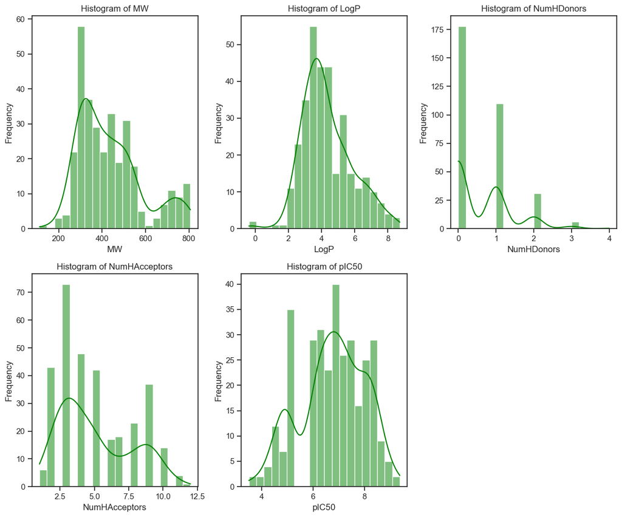

```python
plt.figure(figsize=(12, 10))
numeric_columns = ['MW', 'LogP', 'NumHDonors', 'NumHAcceptors', 'pIC50']
for i, column in enumerate(numeric_columns, 1):
 plt.subplot(2, 3, i) # 2 rows and 3 columns for better layout
 sns.histplot(df_2class[column], kde=True, bins=20,color='green')# kde=True for kernel density estimate
 plt.title(f'Histogram of {column}')
 plt.xlabel(column)
 plt.ylabel('Frequency')
plt.tight_layout()
plt.show()
```

#### Frequency of Bioactivity Classes

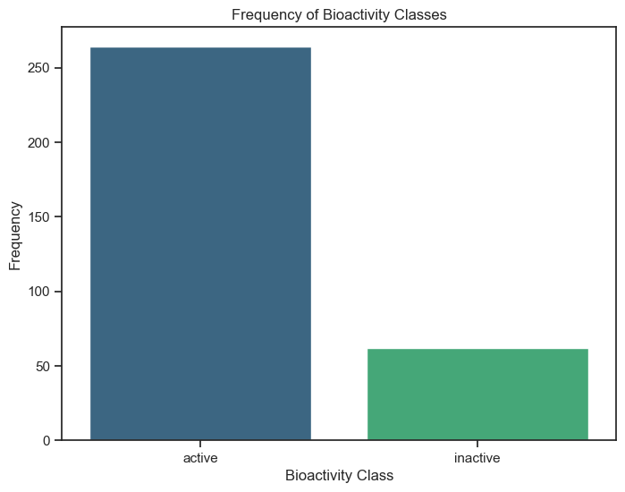

```python
# Set figure size
plt.figure(figsize=(8, 6))
# Count plot with hue
sns.countplot(x='class', hue='class', data=df_2class, palette='viridis')
# Add labels and title
plt.xlabel('Bioactivity Class')
plt.ylabel('Frequency')
plt.title('Frequency of Bioactivity Classes')
# Show plot
plt.show()
```

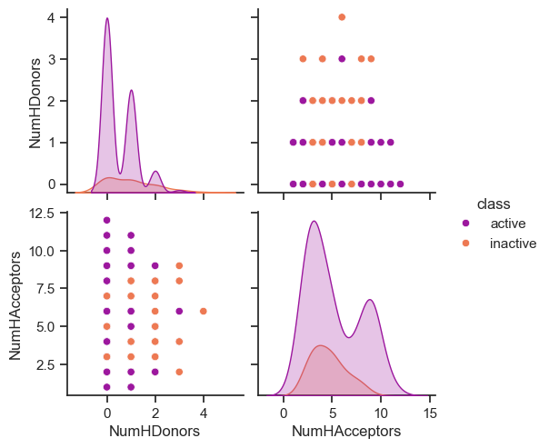

```python
sns.pairplot(df_2class, vars=['NumHDonors', 'NumHAcceptors'], hue='class', palette='plasma')
# Show plot
plt.show()
```

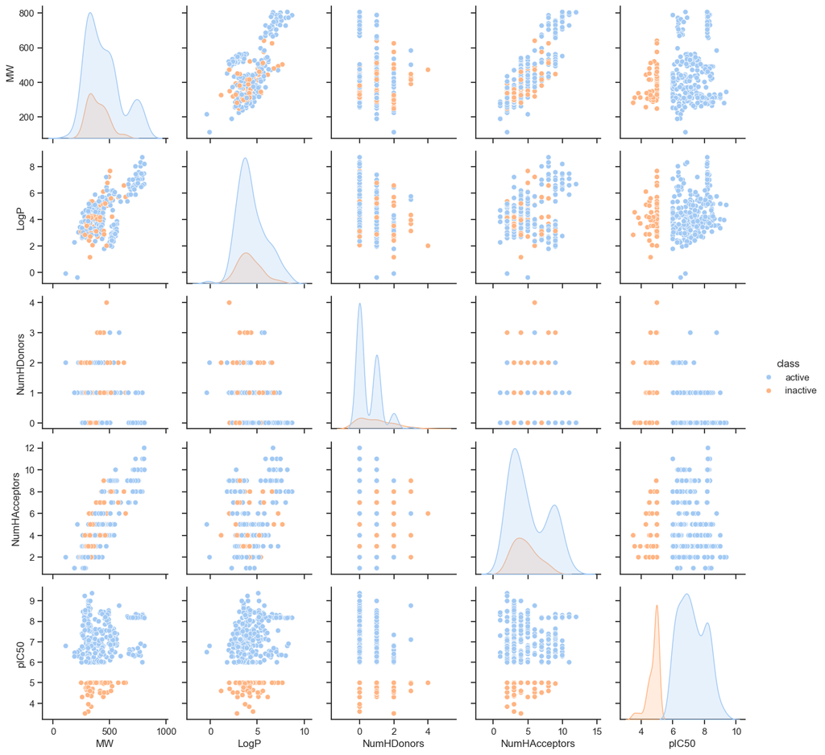

```python
sns.pairplot(df_2class, hue='class', palette='pastel')
# Show plot
plt.show()
```

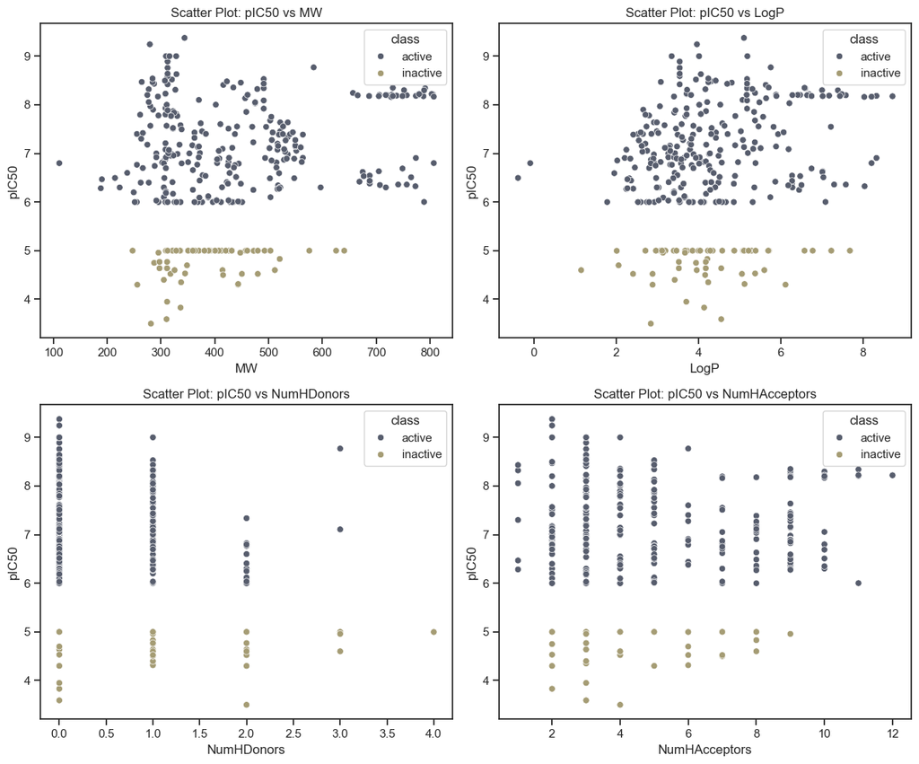

```python
numeric_columns = ['MW', 'LogP', 'NumHDonors', 'NumHAcceptors']
# Set figure size
plt.figure(figsize=(12, 10))
# Loop through numeric columns and create scatter plots
for i, column in enumerate(numeric_columns, 1):
 plt.subplot(2, 2, i) # 2 rows, 2 columns layout
 sns.scatterplot(x=df_2class[column], y=df_2class['pIC50'], hue=df_2class['class'], palette='cividis')
 plt.title(f'Scatter Plot: pIC50 vs {column}')
 plt.xlabel(column)
 plt.ylabel('pIC50')
# Adjust layout
plt.tight_layout()
plt.show()
```

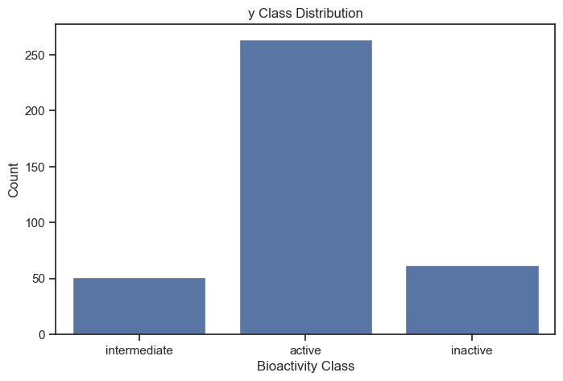

```python
plt.figure(figsize=(8, 5))
sns.countplot(x="class", data=df, )
plt.xlabel("Bioactivity Class")
plt.ylabel("Count")
plt.title("y Class Distribution")
plt.show()
```

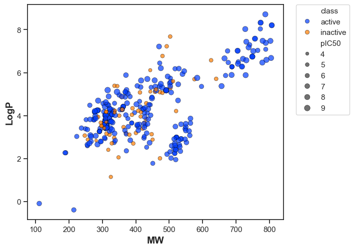

```python
plt.figure(figsize=(6.6, 5.6))
sns.scatterplot(x='MW', y='LogP', data=df_2class, hue='class', size='pIC50',palette='bright', edgecolor='black', alpha=0.7)
plt.xlabel('MW', fontsize=14, fontweight='bold')
plt.ylabel('LogP', fontsize=14, fontweight='bold')
plt.legend(bbox_to_anchor=(1.05, 1), loc=2, borderaxespad=0)
plt.show()
```

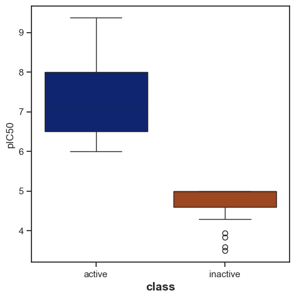

```python
plt.figure(figsize=(5.5, 5.5))
sns.boxplot(x = 'class', y = 'pIC50', data = df_2class, hue = 'class' ,palette = 'dark')
plt.xlabel('class', fontsize=14, fontweight='bold')
```

### Statistical analysis | Mann-Whitney U Test

```python
 # https://machinelearningmastery.com/nonparametric-statistical-significance-tests-in-python/
from numpy.random import seed
from scipy.stats import mannwhitneyu

def mannwhitney(descriptor, verbose=False):
    # Seed the random number generator for reproducibility
    seed(1)

    # Select relevant columns
    selection = [descriptor, 'class']
    df = df_2class[selection]

    # Split active and inactive classes
    active = df[df['class'] == 'active'][descriptor]
    inactive = df[df['class'] == 'inactive'][descriptor]

    # Perform Mann-Whitney U test
    stat, p = mannwhitneyu(active, inactive)

    # Interpret the result
    alpha = 0.05
    interpretation = 'Same distribution (fail to reject H0)' if p > alpha else 'Different distribution (reject H0)'

    # Store results in a DataFrame
    results = pd.DataFrame({
        'Descriptor': [descriptor],
        'Statistics': [stat],
        'p': [p],
        'alpha': [alpha],
        'Interpretation': [interpretation]
    })

    # Save results to CSV
    filename = f'mannwhitneyu_{descriptor}.csv'
    results.to_csv(filename, index=False)

    return results
```

```python
mannwhitney('pIC50')
```

|  | Descriptor | Statistics | p | alpha | Interpretation |
| --- | --- | --- | --- | --- | --- |
| 0 | pIC50 | 16368.0 | 1.454226e-34 | 0.05 | Different distribution (reject H0) |

### MW

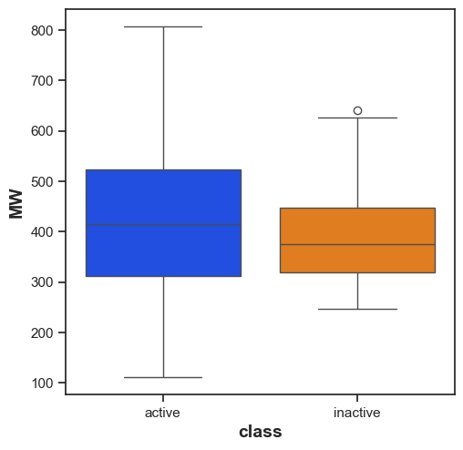

```python
plt.figure(figsize=(5.5, 5.5))
sns.boxplot(x = 'class', y = 'MW', data = df_2class,hue = 'class' , palette = 'bright')
plt.xlabel('class', fontsize=14, fontweight='bold')
plt.ylabel('MW', fontsize=14, fontweight='bold')
```

```python
mannwhitney('MW')
```

|  | Descriptor | Statistics | p | alpha | Interpretation |
| --- | --- | --- | --- | --- | --- |
| 0 | MW | 9443.5 | 0.059407 | 0.05 | Same distribution (fail to reject H0) |

### LogP

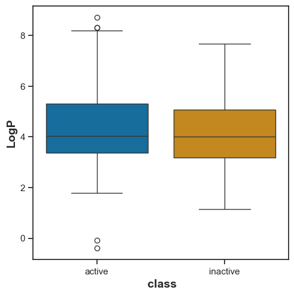

```python
plt.figure(figsize=(5.5, 5.5))

sns.boxplot(x = 'class', y = 'LogP', data = df_2class,hue = 'class' , palette = 'colorblind')

plt.xlabel(' class', fontsize=14, fontweight='bold')
plt.ylabel('LogP', fontsize=14, fontweight='bold')
```

Statistical analysis | Mann-Whitney U Test

```python
mannwhitney('LogP')
```

|  | Descriptor | Statistics | p | alpha | Interpretation |
| --- | --- | --- | --- | --- | --- |
| 0 | LogP | 8681.5 | 0.456767 | 0.05 | Same distribution (fail to reject H0) |

## NumHDonors

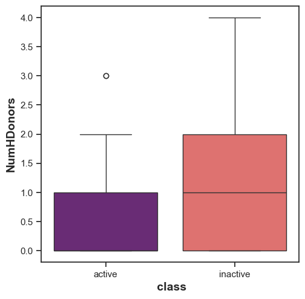

```python
plt.figure(figsize=(5.5, 5.5))
plt.figure(figsize=(5.5, 5.5))
sns.boxplot(x = 'class', y = 'NumHDonors', data = df_2class,hue = 'class' , palette = 'magma')
plt.xlabel(' class', fontsize=14, fontweight='bold')
plt.ylabel('NumHDonors', fontsize=14, fontweight='bold')
```

Statistical analysis | Mann-Whitney U Test

```python
mannwhitney('NumHDonors')
```

|  | Descriptor | Statistics | p | alpha | Interpretation |
| --- | --- | --- | --- | --- | --- |
| 0 | NumHDonors | 6149.5 | 0.000651 | 0.05 | Different distribution (reject H0) |

## NumHAcceptors

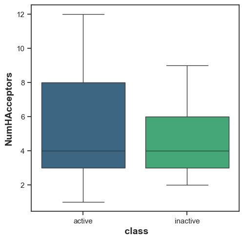

```python
plt.figure(figsize=(5.5, 5.5))

sns.boxplot(x = 'class', y = 'NumHAcceptors', data = df_2class,hue = 'class' , palette = 'viridis')

plt.xlabel(' class', fontsize=14, fontweight='bold')
plt.ylabel('NumHAcceptors', fontsize=14, fontweight='bold')
```

Statistical analysis | Mann-Whitney U Test

```python
mannwhitney('NumHAcceptors')
```

|  | Descriptor | Statistics | p | alpha | Interpretation |
| --- | --- | --- | --- | --- | --- |
| 0 | NumHAcceptors | 8682.0 | 0.451515 | 0.05 | Same distribution (fail to reject H0) |

Box Plots pIC50 values Taking a look at pIC50 values, the actives and inactives displayed statistically significant difference, which is to be expected since threshold values (IC50 < 1,000 nM = Actives while IC50 > 10,000 nM = Inactives, corresponding to pIC50 > 6 = Actives and pIC50 < 5 = Inactives) were used to define actives and inactives.

```python
df3 = pd.read_csv(r"C:\Users\manoj\OneDrive\Desktop\Histamine H1 receptor\Histamine H1 receptor_04_bioactivity_data_3class_pIC50.csv")
```

```python
df3
```

|  | Unnamed: 0 | molecule_chembl_id | canonical_smiles | class | MW | LogP | NumHDonors | NumHAcceptors | pIC50 |
| --- | --- | --- | --- | --- | --- | --- | --- | --- | --- |
| 0 | 2 | CHEMBL24665 | NCCc1c[nH]c(-c2cccc(C(F)(F)F)c2)n1 | active | 255.243000 | 2.59670 | 2.0 | 2.0 | 6.000000 |
| 1 | 4 | CHEMBL94249 | NCCCCCCCCCCc1c[nH]cn1 | active | 223.364000 | 3.03170 | 2.0 | 2.0 | 6.299998 |
| 2 | 5 | CHEMBL157217 | c1nc(CCCCCCCCCCN2CCCC2)c[nH]1 | active | 277.456000 | 4.16880 | 1.0 | 2.0 | 6.399997 |
| 3 | 9 | CHEMBL155188 | NCCCCCCCCCCCCc1c[nH]cn1 | active | 251.418000 | 3.81190 | 2.0 | 2.0 | 6.000000 |
| 4 | 12 | CHEMBL1241 | CN(C)CCN(Cc1ccccc1)c1ccccn1 | active | 255.365000 | 2.64980 | 0.0 | 3.0 | 7.400008 |
| ... | ... | ... | ... | ... | ... | ... | ... | ... | ... |
| 321 | 371 | CHEMBL4519018 | CN1C2CCCC1CC(Nc1ccccc1Br)C2 | active | 309.251000 | 3.87630 | 1.0 | 2.0 | 6.696804 |
| 322 | 373 | CHEMBL5398630 | O=C(O)/C=C/C(=O)O.[2H]C([2H])(Cc1c[nH]c2ccccc1... | active | 190.286204 | 2.27200 | 1.0 | 1.0 | 6.468521 |
| 323 | 374 | CHEMBL3183055 | CN(C)CCc1c[nH]c2ccccc12.O=C(O)/C=C/C(=O)O | active | 188.274000 | 2.27200 | 1.0 | 1.0 | 6.283997 |
| 324 | 375 | CHEMBL2017291 | COc1cc2c(cc1-c1c(C)noc1C)ncc1[nH]c(=O)n([C@H](... | inactive | 415.453000 | 4.16254 | 1.0 | 7.0 | 4.500313 |
| 325 | 376 | CHEMBL3643413 | CCC(=O)N1CC[C@H](Nc2ncnc3c2CN(c2cnc(OC)c(C(F)(... | inactive | 450.465000 | 2.88450 | 1.0 | 7.0 | 4.522879 |

326 rows × 9 columns

```python
df3.head()
```

|  | Unnamed: 0 | molecule_chembl_id | canonical_smiles | class | MW | LogP | NumHDonors | NumHAcceptors | pIC50 |
| --- | --- | --- | --- | --- | --- | --- | --- | --- | --- |
| 0 | 2 | CHEMBL24665 | NCCc1c[nH]c(-c2cccc(C(F)(F)F)c2)n1 | active | 255.243 | 2.5967 | 2.0 | 2.0 | 6.000000 |
| 1 | 4 | CHEMBL94249 | NCCCCCCCCCCc1c[nH]cn1 | active | 223.364 | 3.0317 | 2.0 | 2.0 | 6.299998 |
| 2 | 5 | CHEMBL157217 | c1nc(CCCCCCCCCCN2CCCC2)c[nH]1 | active | 277.456 | 4.1688 | 1.0 | 2.0 | 6.399997 |
| 3 | 9 | CHEMBL155188 | NCCCCCCCCCCCCc1c[nH]cn1 | active | 251.418 | 3.8119 | 2.0 | 2.0 | 6.000000 |
| 4 | 12 | CHEMBL1241 | CN(C)CCN(Cc1ccccc1)c1ccccn1 | active | 255.365 | 2.6498 | 0.0 | 3.0 | 7.400008 |

```python
df3.describe()
```

|  | Unnamed: 0 | MW | LogP | NumHDonors | NumHAcceptors | pIC50 |
| --- | --- | --- | --- | --- | --- | --- |
| count | 326.000000 | 326.000000 | 326.000000 | 326.000000 | 326.000000 | 326.000000 |
| mean | 190.895706 | 434.956041 | 4.331838 | 0.595092 | 5.073620 | 6.760478 |
| std | 107.148013 | 147.782879 | 1.490037 | 0.761683 | 2.632479 | 1.237425 |
| min | 2.000000 | 111.148000 | -0.386300 | 0.000000 | 1.000000 | 3.500000 |
| 25% | 100.250000 | 312.778500 | 3.349175 | 0.000000 | 3.000000 | 6.005044 |
| 50% | 189.500000 | 407.516000 | 4.034560 | 0.000000 | 4.000000 | 6.861769 |
| 75% | 283.750000 | 516.598000 | 5.185950 | 1.000000 | 7.000000 | 7.734490 |
| max | 376.000000 | 806.976000 | 8.715300 | 4.000000 | 12.000000 | 9.375718 |

```python
selection = ['canonical_smiles','molecule_chembl_id']
df3_selection = df3[selection]
df3_selection.to_csv('molecule.smi', sep='\t', index=False, header=False)
```

```python
with open('molecule.smi', 'r') as file:
 for _ in range(5):
     print(file.readline().strip())
```

```
NCCc1c[nH]c(-c2cccc(C(F)(F)F)c2)n1	CHEMBL24665
NCCCCCCCCCCc1c[nH]cn1	CHEMBL94249
c1nc(CCCCCCCCCCN2CCCC2)c[nH]1	CHEMBL157217
NCCCCCCCCCCCCc1c[nH]cn1	CHEMBL155188
CN(C)CCN(Cc1ccccc1)c1ccccn1	CHEMBL1241
```

```python
with open('molecule.smi', 'r') as file:
 line_count = sum(1 for line in file)
print("Total number of lines:", line_count)
```

```
Total number of lines: 326
```

## Preparing the X and Y Data Matrices

```python
X = pd.read_csv(r"C:\Users\manoj\OneDrive\Desktop\New folder\archive\descriptors_output.csv")
```

```python
X
```

|  | Name | PubchemFP0 | PubchemFP1 | PubchemFP2 | PubchemFP3 | PubchemFP4 | PubchemFP5 | PubchemFP6 | PubchemFP7 | PubchemFP8 | ... | PubchemFP871 | PubchemFP872 | PubchemFP873 | PubchemFP874 | PubchemFP875 | PubchemFP876 | PubchemFP877 | PubchemFP878 | PubchemFP879 | PubchemFP880 |
| --- | --- | --- | --- | --- | --- | --- | --- | --- | --- | --- | --- | --- | --- | --- | --- | --- | --- | --- | --- | --- | --- |
| 0 | CHEMBL130478 | 1 | 1 | 0 | 0 | 0 | 0 | 0 | 0 | 0 | ... | 0 | 0 | 0 | 0 | 0 | 0 | 0 | 0 | 0 | 0 |
| 1 | CHEMBL336538 | 1 | 1 | 1 | 0 | 0 | 0 | 0 | 0 | 0 | ... | 0 | 0 | 0 | 0 | 0 | 0 | 0 | 0 | 0 | 0 |
| 2 | CHEMBL339995 | 1 | 1 | 1 | 0 | 0 | 0 | 0 | 0 | 0 | ... | 0 | 0 | 0 | 0 | 0 | 0 | 0 | 0 | 0 | 0 |
| 3 | CHEMBL341437 | 1 | 1 | 1 | 0 | 0 | 0 | 0 | 0 | 0 | ... | 0 | 0 | 0 | 0 | 0 | 0 | 0 | 0 | 0 | 0 |
| 4 | CHEMBL130098 | 1 | 1 | 0 | 0 | 0 | 0 | 0 | 0 | 0 | ... | 0 | 0 | 0 | 0 | 0 | 0 | 0 | 0 | 0 | 0 |
| ... | ... | ... | ... | ... | ... | ... | ... | ... | ... | ... | ... | ... | ... | ... | ... | ... | ... | ... | ... | ... | ... |
| 6941 | CHEMBL253998 | 1 | 1 | 1 | 0 | 0 | 0 | 0 | 0 | 0 | ... | 0 | 0 | 0 | 0 | 0 | 0 | 0 | 0 | 0 | 0 |
| 6942 | CHEMBL502 | 1 | 1 | 1 | 0 | 0 | 0 | 0 | 0 | 0 | ... | 0 | 0 | 0 | 0 | 0 | 0 | 0 | 0 | 0 | 0 |
| 6943 | CHEMBL3085398 | 1 | 1 | 1 | 0 | 0 | 0 | 0 | 0 | 0 | ... | 0 | 0 | 0 | 0 | 0 | 0 | 0 | 0 | 0 | 0 |
| 6944 | CHEMBL13045 | 1 | 1 | 1 | 0 | 0 | 0 | 0 | 0 | 0 | ... | 0 | 0 | 0 | 0 | 0 | 0 | 0 | 0 | 0 | 0 |
| 6945 | CHEMBL417799 | 1 | 1 | 0 | 0 | 0 | 0 | 0 | 0 | 0 | ... | 0 | 0 | 0 | 0 | 0 | 0 | 0 | 0 | 0 | 0 |

6946 rows × 882 columns

```python
X.head(5)
```

|  | Name | PubchemFP0 | PubchemFP1 | PubchemFP2 | PubchemFP3 | PubchemFP4 | PubchemFP5 | PubchemFP6 | PubchemFP7 | PubchemFP8 | ... | PubchemFP871 | PubchemFP872 | PubchemFP873 | PubchemFP874 | PubchemFP875 | PubchemFP876 | PubchemFP877 | PubchemFP878 | PubchemFP879 | PubchemFP880 |
| --- | --- | --- | --- | --- | --- | --- | --- | --- | --- | --- | --- | --- | --- | --- | --- | --- | --- | --- | --- | --- | --- |
| 0 | CHEMBL130478 | 1 | 1 | 0 | 0 | 0 | 0 | 0 | 0 | 0 | ... | 0 | 0 | 0 | 0 | 0 | 0 | 0 | 0 | 0 | 0 |
| 1 | CHEMBL336538 | 1 | 1 | 1 | 0 | 0 | 0 | 0 | 0 | 0 | ... | 0 | 0 | 0 | 0 | 0 | 0 | 0 | 0 | 0 | 0 |
| 2 | CHEMBL339995 | 1 | 1 | 1 | 0 | 0 | 0 | 0 | 0 | 0 | ... | 0 | 0 | 0 | 0 | 0 | 0 | 0 | 0 | 0 | 0 |
| 3 | CHEMBL341437 | 1 | 1 | 1 | 0 | 0 | 0 | 0 | 0 | 0 | ... | 0 | 0 | 0 | 0 | 0 | 0 | 0 | 0 | 0 | 0 |
| 4 | CHEMBL130098 | 1 | 1 | 0 | 0 | 0 | 0 | 0 | 0 | 0 | ... | 0 | 0 | 0 | 0 | 0 | 0 | 0 | 0 | 0 | 0 |

5 rows × 882 columns

```python
X.info()
```

```
<class 'pandas.core.frame.DataFrame'>
RangeIndex: 6946 entries, 0 to 6945
Columns: 882 entries, Name to PubchemFP880
dtypes: int64(881), object(1)
memory usage: 46.7+ MB
```

```python
X.dtypes
```

```
Name            object
PubchemFP0       int64
PubchemFP1       int64
PubchemFP2       int64
PubchemFP3       int64
                 ...
PubchemFP876     int64
PubchemFP877     int64
PubchemFP878     int64
PubchemFP879     int64
PubchemFP880     int64
Length: 882, dtype: object
```

```python
X = X.drop(columns=['Name'])
X
```

|  | PubchemFP0 | PubchemFP1 | PubchemFP2 | PubchemFP3 | PubchemFP4 | PubchemFP5 | PubchemFP6 | PubchemFP7 | PubchemFP8 | PubchemFP9 | ... | PubchemFP871 | PubchemFP872 | PubchemFP873 | PubchemFP874 | PubchemFP875 | PubchemFP876 | PubchemFP877 | PubchemFP878 | PubchemFP879 | PubchemFP880 |
| --- | --- | --- | --- | --- | --- | --- | --- | --- | --- | --- | --- | --- | --- | --- | --- | --- | --- | --- | --- | --- | --- |
| 0 | 1 | 1 | 0 | 0 | 0 | 0 | 0 | 0 | 0 | 1 | ... | 0 | 0 | 0 | 0 | 0 | 0 | 0 | 0 | 0 | 0 |
| 1 | 1 | 1 | 1 | 0 | 0 | 0 | 0 | 0 | 0 | 1 | ... | 0 | 0 | 0 | 0 | 0 | 0 | 0 | 0 | 0 | 0 |
| 2 | 1 | 1 | 1 | 0 | 0 | 0 | 0 | 0 | 0 | 1 | ... | 0 | 0 | 0 | 0 | 0 | 0 | 0 | 0 | 0 | 0 |
| 3 | 1 | 1 | 1 | 0 | 0 | 0 | 0 | 0 | 0 | 1 | ... | 0 | 0 | 0 | 0 | 0 | 0 | 0 | 0 | 0 | 0 |
| 4 | 1 | 1 | 0 | 0 | 0 | 0 | 0 | 0 | 0 | 1 | ... | 0 | 0 | 0 | 0 | 0 | 0 | 0 | 0 | 0 | 0 |
| ... | ... | ... | ... | ... | ... | ... | ... | ... | ... | ... | ... | ... | ... | ... | ... | ... | ... | ... | ... | ... | ... |
| 6941 | 1 | 1 | 1 | 0 | 0 | 0 | 0 | 0 | 0 | 1 | ... | 0 | 0 | 0 | 0 | 0 | 0 | 0 | 0 | 0 | 0 |
| 6942 | 1 | 1 | 1 | 0 | 0 | 0 | 0 | 0 | 0 | 1 | ... | 0 | 0 | 0 | 0 | 0 | 0 | 0 | 0 | 0 | 0 |
| 6943 | 1 | 1 | 1 | 0 | 0 | 0 | 0 | 0 | 0 | 1 | ... | 0 | 0 | 0 | 0 | 0 | 0 | 0 | 0 | 0 | 0 |
| 6944 | 1 | 1 | 1 | 0 | 0 | 0 | 0 | 0 | 0 | 1 | ... | 0 | 0 | 0 | 0 | 0 | 0 | 0 | 0 | 0 | 0 |
| 6945 | 1 | 1 | 0 | 0 | 0 | 0 | 0 | 0 | 0 | 1 | ... | 0 | 0 | 0 | 0 | 0 | 0 | 0 | 0 | 0 | 0 |

6946 rows × 881 columns

## Y variable

```python
y = df3['class']
```

```python
y = y.map({'active': 1, 'inactive': 0})
```

## Split dataset

```python
print("Shape of X:", X.shape)
print("Shape of y:", y.shape)
```

```
Shape of X: (6946, 881)
Shape of y: (326,)
```

```python
X = X.iloc[:y.shape[0], :]  # Trim X to match y
```

```python
print("Shape of X:", X.shape)
print("Shape of y:", y.shape)
```

```
Shape of X: (326, 881)
Shape of y: (326,)
```

```python
from sklearn.model_selection import train_test_split
X_train, X_test, y_train, y_test = train_test_split(X, y, test_size=0.3, random_state=42)
```

```python
from sklearn.preprocessing import StandardScaler
from sklearn.ensemble import RandomForestClassifier
from sklearn.svm import SVC
from sklearn.linear_model import LogisticRegression
from sklearn.metrics import accuracy_score, classification_report, confusion_matrix
```

```python
scaler = StandardScaler()
X_train_scaled = scaler.fit_transform(X_train)
X_test_scaled = scaler.transform(X_test)
```

## Logistic Regression Model

```python
scaler = StandardScaler()
X_train_scaled = scaler.fit_transform(X_train)
X_test_scaled = scaler.transform(X_test)
lr = LogisticRegression(max_iter=500)
```

```python
lr.fit(X_train, y_train)
```

```
LogisticRegression(max_iter=500)
```

```python
y_pred_lr = lr.predict(X_test)
y_pred_lr
```

```
array([1, 1, 1, 1, 1, 1, 1, 1, 1, 1, 1, 1, 1, 1, 1, 1, 1, 1, 1, 1, 1, 1,
       1, 1, 1, 1, 1, 1, 1, 1, 1, 1, 1, 1, 1, 1, 1, 1, 1, 1, 1, 1, 1, 1,
       1, 0, 1, 1, 1, 1, 1, 1, 1, 1, 1, 1, 1, 1, 1, 1, 1, 1, 1, 0, 1, 1,
       1, 1, 1, 1, 1, 1, 1, 1, 1, 1, 1, 1, 1, 1, 1, 1, 1, 0, 0, 1, 1, 1,
       1, 1, 1, 0, 1, 1, 1, 1, 1, 1], dtype=int64)
```

```python
print(classification_report(y_test, y_pred_lr))
```

```
              precision    recall  f1-score   support

           0       0.20      0.06      0.09        18
           1       0.82      0.95      0.88        80

    accuracy                           0.79        98
   macro avg       0.51      0.50      0.48        98
weighted avg       0.70      0.79      0.73        98
```

```python
accuracy = accuracy_score(y_test, y_pred_lr)
print(f"Logistic Regression Model Accuracy: {accuracy * 100:.2f}%")
```

```
Logistic Regression Model Accuracy: 78.57%
```

```
[Text(0, 0.5, 'targeted_label_1'), Text(0, 1.5, 'targeted_label_2')]
```

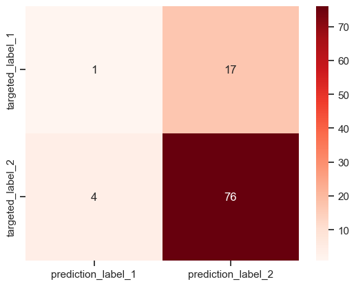

```python
cm = confusion_matrix(y_test, y_pred_lr)
ax = sns.heatmap(cm, annot=True, fmt='d', cmap="Reds")
ax.xaxis.set_ticklabels(['prediction_label_1', 'prediction_label_2' ])
ax.yaxis.set_ticklabels(['targeted_label_1', 'targeted_label_2' ])
```

## Logistic Regression Model Accuracy: 78.57%

```python
from sklearn.tree import DecisionTreeClassifier
DT = DecisionTreeClassifier()
DT.fit(X_train,y_train)
```

```
DecisionTreeClassifier()
```

```python
y_pred_DT = DT.predict(X_test)
y_pred_DT
```

```
array([1, 1, 0, 1, 1, 1, 1, 1, 1, 1, 1, 1, 1, 1, 1, 1, 0, 1, 1, 1, 1, 0,
       0, 0, 1, 0, 1, 1, 0, 0, 1, 1, 0, 0, 1, 1, 1, 1, 1, 1, 1, 1, 1, 1,
       1, 1, 1, 1, 1, 1, 1, 1, 1, 1, 1, 0, 0, 1, 1, 1, 1, 1, 1, 0, 1, 1,
       1, 1, 1, 1, 1, 1, 1, 0, 1, 1, 1, 1, 1, 1, 0, 1, 1, 0, 0, 1, 1, 1,
       1, 1, 1, 1, 1, 1, 1, 1, 1, 1], dtype=int64)
```

```python
print(classification_report(y_test,y_pred_DT))
```

```
              precision    recall  f1-score   support

           0       0.24      0.22      0.23        18
           1       0.83      0.84      0.83        80

    accuracy                           0.72        98
   macro avg       0.53      0.53      0.53        98
weighted avg       0.72      0.72      0.72        98
```

```python
accuracy = accuracy_score(y_test, y_pred_DT)
print(f"DecisionTreeClassifier Model Accuracy: {accuracy * 100:.2f}%")
```

```
DecisionTreeClassifier Model Accuracy: 72.45%
```

```
[Text(0, 0.5, 'targeted_label_1'), Text(0, 1.5, 'targeted_label_2')]
```

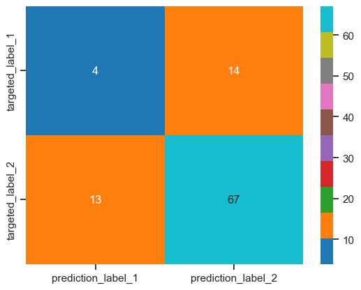

```python
cm = confusion_matrix(y_test, y_pred_DT)
ax = sns.heatmap(cm, annot=True, fmt='d', cmap="tab10")
ax.xaxis.set_ticklabels(['prediction_label_1', 'prediction_label_2' ])
ax.yaxis.set_ticklabels(['targeted_label_1', 'targeted_label_2' ])
```

## DecisionTreeClassifier Model Accuracy: 72.45%

## RandomForestClassifier

```python
rnf = RandomForestClassifier()
rnf.fit(X_train,y_train)
```

```
RandomForestClassifier()
```

```python
y_pred_rnf = rnf.predict(X_test)
y_pred_rnf
```

```
array([1, 1, 1, 1, 1, 1, 1, 1, 1, 1, 1, 1, 1, 1, 1, 1, 1, 1, 1, 1, 1, 0,
       1, 1, 1, 1, 1, 1, 1, 0, 1, 1, 0, 0, 1, 1, 1, 1, 1, 1, 1, 1, 1, 1,
       1, 0, 1, 1, 1, 1, 1, 1, 1, 1, 1, 0, 1, 1, 1, 1, 1, 1, 1, 0, 1, 1,
       1, 1, 1, 1, 1, 1, 1, 0, 1, 1, 1, 1, 1, 1, 0, 1, 1, 1, 1, 1, 1, 1,
       1, 1, 1, 1, 1, 1, 1, 1, 1, 0], dtype=int64)
```

```python
print(classification_report(y_test,y_pred_rnf))
```

```
              precision    recall  f1-score   support

           0       0.30      0.17      0.21        18
           1       0.83      0.91      0.87        80

    accuracy                           0.78        98
   macro avg       0.56      0.54      0.54        98
weighted avg       0.73      0.78      0.75        98
```

```python
accuracy = accuracy_score(y_test, y_pred_rnf)
print(f"RandomForestClassifier Model Accuracy: {accuracy * 100:.2f}%")
```

```
RandomForestClassifier Model Accuracy: 77.55%
```

```
[Text(0, 0.5, 'targeted_label_1'), Text(0, 1.5, 'targeted_label_2')]
```

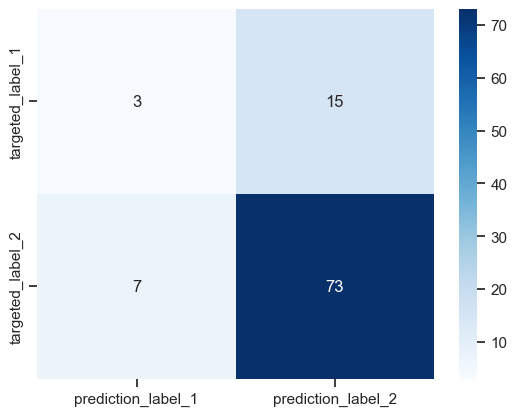

```python
cm = confusion_matrix(y_test, y_pred_rnf)
ax = sns.heatmap(cm, annot=True, fmt='d', cmap="Blues")
ax.xaxis.set_ticklabels(['prediction_label_1', 'prediction_label_2' ])
ax.yaxis.set_ticklabels(['targeted_label_1', 'targeted_label_2' ])
```

## RandomForestClassifier Model Accuracy: 77.55%

## K-Nearest Neighbors (KNN)

```python
from sklearn.neighbors import KNeighborsClassifier
knn = KNeighborsClassifier(n_neighbors=5)
knn.fit(X_train,y_train)
```

```
KNeighborsClassifier()
```

```python
y_pred_knn = knn.predict(X_test)
y_pred_knn
```

```
array([1, 1, 1, 1, 1, 1, 1, 1, 1, 1, 1, 1, 1, 1, 1, 1, 1, 1, 1, 1, 1, 1,
       1, 1, 1, 1, 1, 1, 1, 1, 1, 1, 1, 1, 1, 1, 1, 1, 1, 1, 1, 1, 1, 1,
       1, 1, 1, 1, 1, 1, 1, 1, 1, 1, 1, 1, 1, 1, 1, 1, 1, 1, 1, 0, 1, 1,
       1, 1, 1, 1, 1, 1, 1, 1, 1, 1, 1, 1, 1, 1, 1, 1, 1, 1, 1, 1, 1, 1,
       1, 1, 1, 0, 1, 1, 1, 1, 1, 1], dtype=int64)
```

```python
print(classification_report(y_test,y_pred_knn))
```

```
              precision    recall  f1-score   support

           0       0.50      0.06      0.10        18
           1       0.82      0.99      0.90        80

    accuracy                           0.82        98
   macro avg       0.66      0.52      0.50        98
weighted avg       0.76      0.82      0.75        98
```

```python
accuracy = accuracy_score(y_test, y_pred_knn)
print(f"KNeighborsClassifier Model Accuracy: {accuracy * 100:.2f}%")
```

```
KNeighborsClassifier Model Accuracy: 81.63%
```

```
[Text(0, 0.5, 'targeted_label_1'), Text(0, 1.5, 'targeted_label_2')]
```

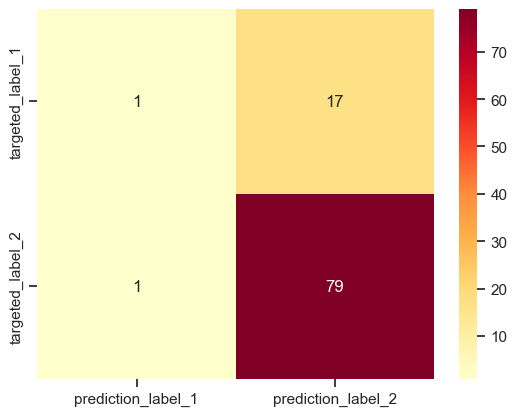

```python
cm = confusion_matrix(y_test, y_pred_knn)
ax = sns.heatmap(cm, annot=True, fmt='d', cmap="YlOrRd")
ax.xaxis.set_ticklabels(['prediction_label_1', 'prediction_label_2' ])
ax.yaxis.set_ticklabels(['targeted_label_1', 'targeted_label_2' ])
```

## KNeighborsClassifier Model Accuracy: 81.63%

```python
df3_X = pd.read_csv(r"C:\Users\manoj\OneDrive\Desktop\New folder\archive\descriptors_output.csv")
```

```python
df3_X
```

|  | Name | PubchemFP0 | PubchemFP1 | PubchemFP2 | PubchemFP3 | PubchemFP4 | PubchemFP5 | PubchemFP6 | PubchemFP7 | PubchemFP8 | ... | PubchemFP871 | PubchemFP872 | PubchemFP873 | PubchemFP874 | PubchemFP875 | PubchemFP876 | PubchemFP877 | PubchemFP878 | PubchemFP879 | PubchemFP880 |
| --- | --- | --- | --- | --- | --- | --- | --- | --- | --- | --- | --- | --- | --- | --- | --- | --- | --- | --- | --- | --- | --- |
| 0 | CHEMBL130478 | 1 | 1 | 0 | 0 | 0 | 0 | 0 | 0 | 0 | ... | 0 | 0 | 0 | 0 | 0 | 0 | 0 | 0 | 0 | 0 |
| 1 | CHEMBL336538 | 1 | 1 | 1 | 0 | 0 | 0 | 0 | 0 | 0 | ... | 0 | 0 | 0 | 0 | 0 | 0 | 0 | 0 | 0 | 0 |
| 2 | CHEMBL339995 | 1 | 1 | 1 | 0 | 0 | 0 | 0 | 0 | 0 | ... | 0 | 0 | 0 | 0 | 0 | 0 | 0 | 0 | 0 | 0 |
| 3 | CHEMBL341437 | 1 | 1 | 1 | 0 | 0 | 0 | 0 | 0 | 0 | ... | 0 | 0 | 0 | 0 | 0 | 0 | 0 | 0 | 0 | 0 |
| 4 | CHEMBL130098 | 1 | 1 | 0 | 0 | 0 | 0 | 0 | 0 | 0 | ... | 0 | 0 | 0 | 0 | 0 | 0 | 0 | 0 | 0 | 0 |
| ... | ... | ... | ... | ... | ... | ... | ... | ... | ... | ... | ... | ... | ... | ... | ... | ... | ... | ... | ... | ... | ... |
| 6941 | CHEMBL253998 | 1 | 1 | 1 | 0 | 0 | 0 | 0 | 0 | 0 | ... | 0 | 0 | 0 | 0 | 0 | 0 | 0 | 0 | 0 | 0 |
| 6942 | CHEMBL502 | 1 | 1 | 1 | 0 | 0 | 0 | 0 | 0 | 0 | ... | 0 | 0 | 0 | 0 | 0 | 0 | 0 | 0 | 0 | 0 |
| 6943 | CHEMBL3085398 | 1 | 1 | 1 | 0 | 0 | 0 | 0 | 0 | 0 | ... | 0 | 0 | 0 | 0 | 0 | 0 | 0 | 0 | 0 | 0 |
| 6944 | CHEMBL13045 | 1 | 1 | 1 | 0 | 0 | 0 | 0 | 0 | 0 | ... | 0 | 0 | 0 | 0 | 0 | 0 | 0 | 0 | 0 | 0 |
| 6945 | CHEMBL417799 | 1 | 1 | 0 | 0 | 0 | 0 | 0 | 0 | 0 | ... | 0 | 0 | 0 | 0 | 0 | 0 | 0 | 0 | 0 | 0 |

6946 rows × 882 columns

```python
df3_X = df3_X.drop(columns=['Name'])
df3_X
```

|  | PubchemFP0 | PubchemFP1 | PubchemFP2 | PubchemFP3 | PubchemFP4 | PubchemFP5 | PubchemFP6 | PubchemFP7 | PubchemFP8 | PubchemFP9 | ... | PubchemFP871 | PubchemFP872 | PubchemFP873 | PubchemFP874 | PubchemFP875 | PubchemFP876 | PubchemFP877 | PubchemFP878 | PubchemFP879 | PubchemFP880 |
| --- | --- | --- | --- | --- | --- | --- | --- | --- | --- | --- | --- | --- | --- | --- | --- | --- | --- | --- | --- | --- | --- |
| 0 | 1 | 1 | 0 | 0 | 0 | 0 | 0 | 0 | 0 | 1 | ... | 0 | 0 | 0 | 0 | 0 | 0 | 0 | 0 | 0 | 0 |
| 1 | 1 | 1 | 1 | 0 | 0 | 0 | 0 | 0 | 0 | 1 | ... | 0 | 0 | 0 | 0 | 0 | 0 | 0 | 0 | 0 | 0 |
| 2 | 1 | 1 | 1 | 0 | 0 | 0 | 0 | 0 | 0 | 1 | ... | 0 | 0 | 0 | 0 | 0 | 0 | 0 | 0 | 0 | 0 |
| 3 | 1 | 1 | 1 | 0 | 0 | 0 | 0 | 0 | 0 | 1 | ... | 0 | 0 | 0 | 0 | 0 | 0 | 0 | 0 | 0 | 0 |
| 4 | 1 | 1 | 0 | 0 | 0 | 0 | 0 | 0 | 0 | 1 | ... | 0 | 0 | 0 | 0 | 0 | 0 | 0 | 0 | 0 | 0 |
| ... | ... | ... | ... | ... | ... | ... | ... | ... | ... | ... | ... | ... | ... | ... | ... | ... | ... | ... | ... | ... | ... |
| 6941 | 1 | 1 | 1 | 0 | 0 | 0 | 0 | 0 | 0 | 1 | ... | 0 | 0 | 0 | 0 | 0 | 0 | 0 | 0 | 0 | 0 |
| 6942 | 1 | 1 | 1 | 0 | 0 | 0 | 0 | 0 | 0 | 1 | ... | 0 | 0 | 0 | 0 | 0 | 0 | 0 | 0 | 0 | 0 |
| 6943 | 1 | 1 | 1 | 0 | 0 | 0 | 0 | 0 | 0 | 1 | ... | 0 | 0 | 0 | 0 | 0 | 0 | 0 | 0 | 0 | 0 |
| 6944 | 1 | 1 | 1 | 0 | 0 | 0 | 0 | 0 | 0 | 1 | ... | 0 | 0 | 0 | 0 | 0 | 0 | 0 | 0 | 0 | 0 |
| 6945 | 1 | 1 | 0 | 0 | 0 | 0 | 0 | 0 | 0 | 1 | ... | 0 | 0 | 0 | 0 | 0 | 0 | 0 | 0 | 0 | 0 |

6946 rows × 881 columns

```python
Y = df3['pIC50']
Y
```

```
0     6.00
1     6.30
2     6.40
3     6.00
4     7.40
      ...
321   6.70
322   6.47
323   6.28
324   4.50
325   4.52
Name: pIC50, Length: 326, dtype: float64
```

```python
dataset3 = pd.concat([df3_X,df3_Y], axis=1)
dataset3
```

|  | PubchemFP0 | PubchemFP1 | PubchemFP2 | PubchemFP3 | PubchemFP4 | PubchemFP5 | PubchemFP6 | PubchemFP7 | PubchemFP8 | PubchemFP9 | ... | PubchemFP872 | PubchemFP873 | PubchemFP874 | PubchemFP875 | PubchemFP876 | PubchemFP877 | PubchemFP878 | PubchemFP879 | PubchemFP880 | pIC50 |
| --- | --- | --- | --- | --- | --- | --- | --- | --- | --- | --- | --- | --- | --- | --- | --- | --- | --- | --- | --- | --- | --- |
| 0 | 1 | 1 | 0 | 0 | 0 | 0 | 0 | 0 | 0 | 1 | ... | 0 | 0 | 0 | 0 | 0 | 0 | 0 | 0 | 0 | 6.00 |
| 1 | 1 | 1 | 1 | 0 | 0 | 0 | 0 | 0 | 0 | 1 | ... | 0 | 0 | 0 | 0 | 0 | 0 | 0 | 0 | 0 | 6.30 |
| 2 | 1 | 1 | 1 | 0 | 0 | 0 | 0 | 0 | 0 | 1 | ... | 0 | 0 | 0 | 0 | 0 | 0 | 0 | 0 | 0 | 6.40 |
| 3 | 1 | 1 | 1 | 0 | 0 | 0 | 0 | 0 | 0 | 1 | ... | 0 | 0 | 0 | 0 | 0 | 0 | 0 | 0 | 0 | 6.00 |
| 4 | 1 | 1 | 0 | 0 | 0 | 0 | 0 | 0 | 0 | 1 | ... | 0 | 0 | 0 | 0 | 0 | 0 | 0 | 0 | 0 | 7.40 |
| ... | ... | ... | ... | ... | ... | ... | ... | ... | ... | ... | ... | ... | ... | ... | ... | ... | ... | ... | ... | ... | ... |
| 6941 | 1 | 1 | 1 | 0 | 0 | 0 | 0 | 0 | 0 | 1 | ... | 0 | 0 | 0 | 0 | 0 | 0 | 0 | 0 | 0 | NaN |
| 6942 | 1 | 1 | 1 | 0 | 0 | 0 | 0 | 0 | 0 | 1 | ... | 0 | 0 | 0 | 0 | 0 | 0 | 0 | 0 | 0 | NaN |
| 6943 | 1 | 1 | 1 | 0 | 0 | 0 | 0 | 0 | 0 | 1 | ... | 0 | 0 | 0 | 0 | 0 | 0 | 0 | 0 | 0 | NaN |
| 6944 | 1 | 1 | 1 | 0 | 0 | 0 | 0 | 0 | 0 | 1 | ... | 0 | 0 | 0 | 0 | 0 | 0 | 0 | 0 | 0 | NaN |
| 6945 | 1 | 1 | 0 | 0 | 0 | 0 | 0 | 0 | 0 | 1 | ... | 0 | 0 | 0 | 0 | 0 | 0 | 0 | 0 | 0 | NaN |

6946 rows × 882 columns

```python
from sklearn.model_selection import train_test_split
import lazypredict
from lazypredict.Supervised import LazyRegressor
```

```python
X.shape
```

[output not shown]

```python
# Remove low variance features
from sklearn.feature_selection import VarianceThreshold
selection = VarianceThreshold(threshold=(.8 * (1 - .8)))
X = selection.fit_transform(X)
X.shape
```

```
(326, 129)
```

```python
X_train, X_test, Y_train, Y_test = train_test_split(X, Y, test_size=0.2, random_state=42)
```

```python
clf = LazyRegressor(verbose=0,ignore_warnings=True, custom_metric=None)
models_train,predictions_train = clf.fit(X_train, X_train, Y_train, Y_train)
models_test,predictions_test = clf.fit(X_train, X_test, Y_train, Y_test)
```

[output not shown]

[output cut: 53 more lines]

[output not shown]

[output not shown]

[output cut: 51 more lines]

[output not shown]

```python
predictions_train
```

| Model | Adjusted R-Squared | R-Squared | RMSE | Time Taken |
| --- | --- | --- | --- | --- |
| DecisionTreeRegressor | 0.23 | 0.61 | 0.77 | 0.04 |
| ExtraTreeRegressor | 0.23 | 0.61 | 0.77 | 0.05 |
| ExtraTreesRegressor | 0.23 | 0.61 | 0.77 | 1.20 |
| GaussianProcessRegressor | 0.23 | 0.61 | 0.77 | 0.07 |
| XGBRegressor | 0.23 | 0.61 | 0.77 | 1.39 |
| RandomForestRegressor | 0.03 | 0.51 | 0.86 | 1.11 |
| BaggingRegressor | -0.04 | 0.48 | 0.90 | 0.14 |
| MLPRegressor | -0.22 | 0.39 | 0.97 | 1.68 |
| GradientBoostingRegressor | -0.23 | 0.38 | 0.97 | 0.45 |
| HistGradientBoostingRegressor | -0.34 | 0.33 | 1.02 | 0.68 |
| LGBMRegressor | -0.35 | 0.32 | 1.02 | 0.16 |
| Ridge | -0.43 | 0.28 | 1.05 | 0.04 |
| RidgeCV | -0.53 | 0.23 | 1.09 | 0.06 |
| HuberRegressor | -0.58 | 0.21 | 1.10 | 0.21 |
| SGDRegressor | -0.63 | 0.18 | 1.12 | 0.04 |
| PoissonRegressor | -0.64 | 0.18 | 1.12 | 0.07 |
| NuSVR | -0.67 | 0.16 | 1.13 | 0.06 |
| LinearSVR | -0.71 | 0.14 | 1.15 | 0.13 |
| SVR | -0.76 | 0.11 | 1.17 | 0.07 |
| AdaBoostRegressor | -0.78 | 0.11 | 1.17 | 0.10 |
| OrthogonalMatchingPursuit | -0.78 | 0.11 | 1.17 | 0.04 |
| KNeighborsRegressor | -0.79 | 0.10 | 1.17 | 0.06 |
| TweedieRegressor | -0.81 | 0.09 | 1.18 | 0.06 |
| GammaRegressor | -0.81 | 0.09 | 1.18 | 0.23 |
| LarsCV | -0.94 | 0.02 | 1.22 | 0.51 |
| OrthogonalMatchingPursuitCV | -0.95 | 0.02 | 1.23 | 0.08 |
| BayesianRidge | -0.99 | 0.00 | 1.24 | 0.09 |
| LassoLars | -0.99 | 0.00 | 1.24 | 0.03 |
| DummyRegressor | -0.99 | 0.00 | 1.24 | 0.03 |
| ElasticNet | -0.99 | 0.00 | 1.24 | 0.04 |
| ElasticNetCV | -0.99 | 0.00 | 1.24 | 10.28 |
| LassoLarsCV | -0.99 | 0.00 | 1.24 | 0.20 |
| LassoCV | -0.99 | 0.00 | 1.24 | 7.27 |
| Lasso | -0.99 | 0.00 | 1.24 | 0.03 |
| LassoLarsIC | -0.99 | 0.00 | 1.24 | 0.10 |
| QuantileRegressor | -1.01 | -0.01 | 1.25 | 0.13 |
| PassiveAggressiveRegressor | -1.81 | -0.41 | 1.47 | 0.04 |
| TransformedTargetRegressor | -1.84 | -0.43 | 1.48 | 0.04 |
| LinearRegression | -1.84 | -0.43 | 1.48 | 0.16 |
| KernelRidge | -58.83 | -29.03 | 6.79 | 0.04 |
| RANSACRegressor | -3462091539051886053163008.00 | -1737729343925657033244672.00 | 1633586300395.05 | 1.13 |
| Lars | -4494631175055414254454702080.00 | -2255992481688045817849446400.00 | 58859943278549.79 | 0.12 |

```python
predictions_test
```

| Model | Adjusted R-Squared | R-Squared | RMSE | Time Taken |
| --- | --- | --- | --- | --- |
| Lars | 34935877234292879230979793899081844945700065273... | -3439840219991914377771971649911932195944540489... | 22251288860532704924401664.00 | 0.12 |
| LinearRegression | 302224660895320728666112.00 | -297575050727700402536448.00 | 654461788358.76 | 0.04 |
| TransformedTargetRegressor | 302224660895320728666112.00 | -297575050727700402536448.00 | 654461788358.76 | 0.05 |
| RANSACRegressor | 120029513136298050715648.00 | -118182905241893471256576.00 | 412442459052.08 | 1.14 |
| KernelRidge | 36.32 | -33.78 | 7.08 | 0.04 |
| GaussianProcessRegressor | 15.73 | -13.50 | 4.57 | 0.05 |
| PassiveAggressiveRegressor | 3.01 | -0.98 | 1.69 | 0.04 |
| DecisionTreeRegressor | 2.87 | -0.84 | 1.63 | 0.04 |
| ExtraTreesRegressor | 2.77 | -0.75 | 1.58 | 1.24 |
| XGBRegressor | 2.71 | -0.68 | 1.56 | 0.36 |
| ExtraTreeRegressor | 2.69 | -0.66 | 1.55 | 0.04 |
| HuberRegressor | 2.67 | -0.64 | 1.54 | 0.20 |
| LinearSVR | 2.62 | -0.60 | 1.52 | 0.13 |
| MLPRegressor | 2.59 | -0.56 | 1.50 | 1.81 |
| Ridge | 2.58 | -0.55 | 1.50 | 0.04 |
| BaggingRegressor | 2.47 | -0.44 | 1.44 | 0.16 |
| RandomForestRegressor | 2.35 | -0.33 | 1.38 | 1.09 |
| RidgeCV | 2.32 | -0.30 | 1.37 | 0.06 |
| SGDRegressor | 2.29 | -0.27 | 1.35 | 0.04 |
| KNeighborsRegressor | 2.24 | -0.22 | 1.33 | 0.05 |
| GradientBoostingRegressor | 2.22 | -0.21 | 1.32 | 0.47 |
| PoissonRegressor | 2.19 | -0.17 | 1.30 | 0.07 |
| LGBMRegressor | 2.17 | -0.15 | 1.29 | 0.22 |
| HistGradientBoostingRegressor | 2.15 | -0.13 | 1.28 | 0.64 |
| AdaBoostRegressor | 2.12 | -0.11 | 1.26 | 0.11 |
| OrthogonalMatchingPursuit | 2.09 | -0.08 | 1.24 | 0.03 |
| GammaRegressor | 2.07 | -0.06 | 1.23 | 0.05 |
| TweedieRegressor | 2.07 | -0.05 | 1.23 | 0.07 |
| LassoLarsIC | 2.06 | -0.04 | 1.23 | 0.08 |
| DummyRegressor | 2.06 | -0.04 | 1.23 | 0.03 |
| ElasticNet | 2.06 | -0.04 | 1.23 | 0.03 |
| ElasticNetCV | 2.06 | -0.04 | 1.23 | 8.83 |
| LassoLarsCV | 2.06 | -0.04 | 1.23 | 0.20 |
| Lasso | 2.06 | -0.04 | 1.23 | 0.03 |
| LassoCV | 2.06 | -0.04 | 1.23 | 7.25 |
| LassoLars | 2.06 | -0.04 | 1.23 | 0.03 |
| BayesianRidge | 2.06 | -0.04 | 1.22 | 0.08 |
| SVR | 2.04 | -0.03 | 1.22 | 0.06 |
| OrthogonalMatchingPursuitCV | 2.04 | -0.02 | 1.21 | 0.08 |
| LarsCV | 2.04 | -0.02 | 1.21 | 0.51 |
| QuantileRegressor | 2.03 | -0.01 | 1.21 | 0.12 |
| NuSVR | 2.01 | 0.00 | 1.20 | 0.05 |

### Bar plot of R-squared values

```
[(0.0, 1.0)]
```

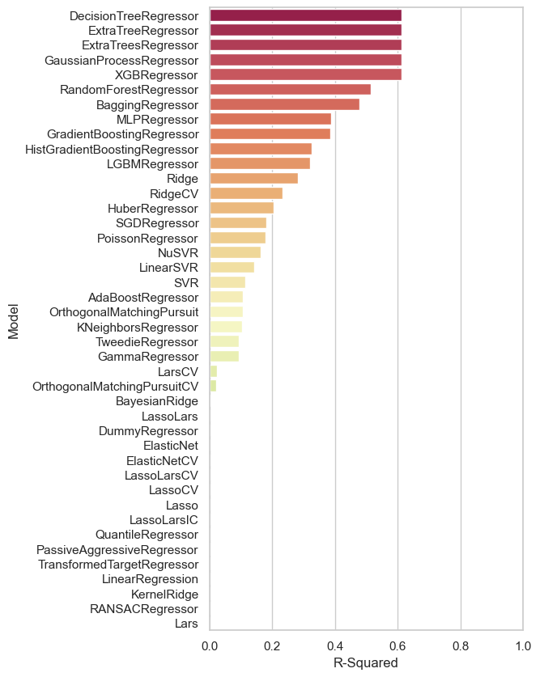

```python
#train["R-Squared"] = [0 if i < 0 else i for i in train.iloc[:,0] ]

plt.figure(figsize=(5, 10))
sns.set_theme(style="whitegrid")
ax = sns.barplot(y=predictions_train.index, x="R-Squared", data=predictions_train,palette=sns.color_palette("Spectral", len(predictions_train)))
ax.set(xlim=(0, 1))
```

Bar plot of RMSE values

```
[(0.0, 10.0)]
```

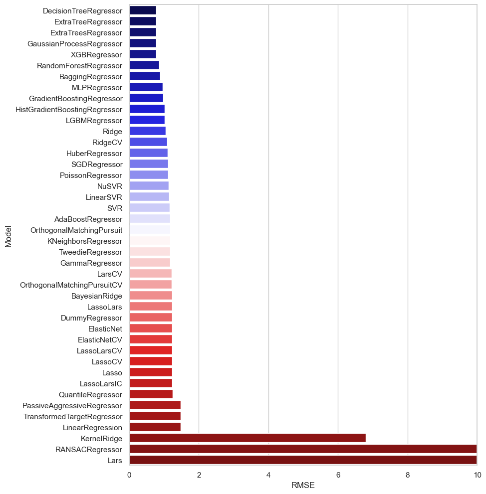

```python
plt.figure(figsize=(9, 12))
sns.set_theme(style="whitegrid")
ax = sns.barplot(y=predictions_train.index, x="RMSE", data=predictions_train,palette=sns.color_palette("seismic", len(predictions_train)))
ax.set(xlim=(0, 10))
```

## Bar plot of calculation time

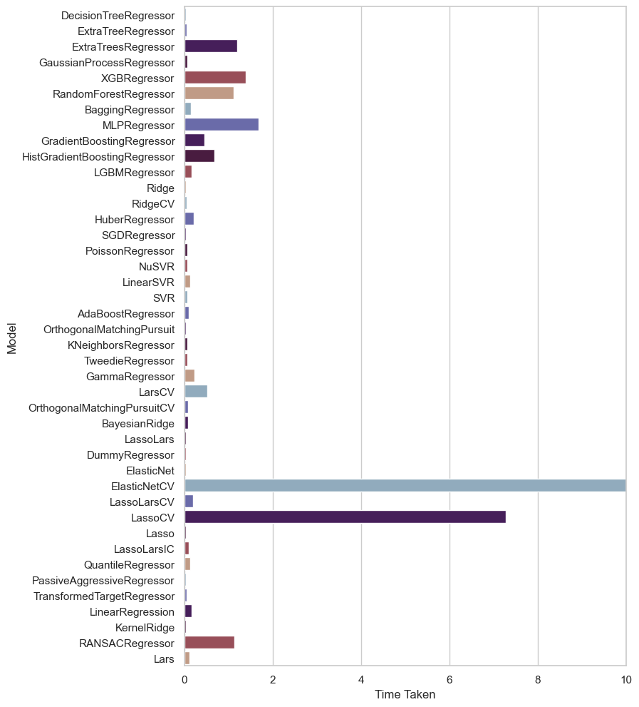

```python
plt.figure(figsize=(8, 12))
sns.set_theme(style="whitegrid")

ax = sns.barplot(y=predictions_train.index, x="Time Taken", data=predictions_train,
                 palette=sns.color_palette("twilight"))

ax.set(xlim=(0, 10))
plt.show()
```